# Math-Madness 2024

Author: Mitch Fairweather

Welcome to my March Madness notebook! I hope you are able to take something interesting away from this, potentially even using this to build your very own bracket for March Madness.

The intersection between analytics and sports has always been a passion of mine for as long as I can remember, as is building a bracket come March every year. With 64 teams competing in a single elimination tournament, it can be incredibly daunting trying to pick who will be your champion, who will upset who, which top seed is going to bust, etc. It is no wonder why so many people turn to non-traditional methods for building their brackets - picking their favorite mascots, favorite team colors, or maybe throwing darts on a wall and see which team you hit. Often times, these methods seem to result in a fairly successful bracket! It goes to show how much luck there really is.

My approach is a little bit different. What if we can predict the winners of each matchup using computer algorithms? Will it result in achieving the elusive "perfect bracket"?

- Notebook Preparation
  - Packages Used
  - Read in Data
- Data Preparation
  - Team Quality Rankings
  - Adjusted Box Score Metrics
- Prepare Tournament Data
  - Matchup Data with Adjusted Box Score Metrics
- Model Building
  - XGBoost Hyperparameter Tuning
  - Final XGBoost Models
  - LightGBM Hyperparameter Tuning
  - Final LightGBM Models
  - Ensemble Methods
  - Final Model Results
- Application of Results: Building Brackets
  - Prepare 2024 Data
  - Building Mens Brackets for 2024 Tournament
  - Building Womens Brackets for 2024 Tournament
- Final Thoughts

# Notebook Preparation

This notebook is used to compete in the "March Machine Learning Mania" competition on Kaggle ever year. As such, all data sources come directly from the competition. I've opted not to bring in any third-party data sources to keep it as simple as possible.

## Packages Used

```python
import numpy as np
import pandas as pd
import statsmodels.api as sm
import sklearn
from sklearn.linear_model import LogisticRegression
from sklearn.linear_model import LinearRegression
from sklearn.ensemble import GradientBoostingRegressor
from sklearn.preprocessing import StandardScaler, RobustScaler
from functools import reduce
import csv
import itertools
from hyperopt import fmin,anneal, hp, STATUS_OK, Trials
from hyperopt.early_stop import no_progress_loss
import xgboost as xgb
from sklearn.metrics import log_loss
import lightgbm
import copy
from tqdm import tqdm
import matplotlib.pyplot as plt
import seaborn as sns
import plotly.express as px
import plotly.graph_objects as go
```

```python
pd.set_option('display.max_rows', 100)
pd.set_option('display.max_columns', 100)
pd.set_option('display.width', 1000)
```

## Reading in Data

### Tournament Seed Data

```python
seeds_m = pd.read_csv(r'/kaggle/input/march-machine-learning-mania-2024/MNCAATourneySeeds.csv')
seeds_w = pd.read_csv(r'/kaggle/input/march-machine-learning-mania-2024/WNCAATourneySeeds.csv')

seeds_m['Season'] = seeds_m['Season'].astype(str)
seeds_m['TeamID'] = seeds_m['TeamID'].astype(str)

seeds_w['Season'] = seeds_w['Season'].astype(str)
seeds_w['TeamID'] = seeds_w['TeamID'].astype(str)
```

```python
seeds_m.head()
```

|  | Season | Seed | TeamID |
| --- | --- | --- | --- |
| 0 | 1985 | W01 | 1207 |
| 1 | 1985 | W02 | 1210 |
| 2 | 1985 | W03 | 1228 |
| 3 | 1985 | W04 | 1260 |
| 4 | 1985 | W05 | 1374 |

### Regular Season Result Data

```python
regular_results_detailed_m = pd.read_csv(r'/kaggle/input/march-machine-learning-mania-2024/MRegularSeasonDetailedResults.csv')
regular_results_detailed_w = pd.read_csv(r'/kaggle/input/march-machine-learning-mania-2024/WRegularSeasonDetailedResults.csv')
```

```python
regular_results_detailed_m.head()
```

|  | Season | DayNum | WTeamID | WScore | LTeamID | LScore | WLoc | NumOT | WFGM | WFGA | WFGM3 | WFGA3 | WFTM | WFTA | WOR | WDR | WAst | WTO | WStl | WBlk | WPF | LFGM | LFGA | LFGM3 | LFGA3 | LFTM | LFTA | LOR | LDR | … |
| --- | --- | --- | --- | --- | --- | --- | --- | --- | --- | --- | --- | --- | --- | --- | --- | --- | --- | --- | --- | --- | --- | --- | --- | --- | --- | --- | --- | --- | --- | --- |
| 0 | 2003 | 10 | 1104 | 68 | 1328 | 62 | N | 0 | 27 | 58 | 3 | 14 | 11 | 18 | 14 | 24 | 13 | 23 | 7 | 1 | 22 | 22 | 53 | 2 | 10 | 16 | 22 | 10 | 22 | … |
| 1 | 2003 | 10 | 1272 | 70 | 1393 | 63 | N | 0 | 26 | 62 | 8 | 20 | 10 | 19 | 15 | 28 | 16 | 13 | 4 | 4 | 18 | 24 | 67 | 6 | 24 | 9 | 20 | 20 | 25 | … |
| 2 | 2003 | 11 | 1266 | 73 | 1437 | 61 | N | 0 | 24 | 58 | 8 | 18 | 17 | 29 | 17 | 26 | 15 | 10 | 5 | 2 | 25 | 22 | 73 | 3 | 26 | 14 | 23 | 31 | 22 | … |
| 3 | 2003 | 11 | 1296 | 56 | 1457 | 50 | N | 0 | 18 | 38 | 3 | 9 | 17 | 31 | 6 | 19 | 11 | 12 | 14 | 2 | 18 | 18 | 49 | 6 | 22 | 8 | 15 | 17 | 20 | … |
| 4 | 2003 | 11 | 1400 | 77 | 1208 | 71 | N | 0 | 30 | 61 | 6 | 14 | 11 | 13 | 17 | 22 | 12 | 14 | 4 | 4 | 20 | 24 | 62 | 6 | 16 | 17 | 27 | 21 | 15 | … |

### Tournament Result Data

```python
tourney_results_detailed_m = pd.read_csv(r'/kaggle/input/march-machine-learning-mania-2024/MNCAATourneyDetailedResults.csv')
tourney_results_detailed_w = pd.read_csv(r'/kaggle/input/march-machine-learning-mania-2024/WNCAATourneyDetailedResults.csv')
```

```python
tourney_results_detailed_m.head()
```

|  | Season | DayNum | WTeamID | WScore | LTeamID | LScore | WLoc | NumOT | WFGM | WFGA | WFGM3 | WFGA3 | WFTM | WFTA | WOR | WDR | WAst | WTO | WStl | WBlk | WPF | LFGM | LFGA | LFGM3 | LFGA3 | LFTM | LFTA | LOR | LDR | … |
| --- | --- | --- | --- | --- | --- | --- | --- | --- | --- | --- | --- | --- | --- | --- | --- | --- | --- | --- | --- | --- | --- | --- | --- | --- | --- | --- | --- | --- | --- | --- |
| 0 | 2003 | 134 | 1421 | 92 | 1411 | 84 | N | 1 | 32 | 69 | 11 | 29 | 17 | 26 | 14 | 30 | 17 | 12 | 5 | 3 | 22 | 29 | 67 | 12 | 31 | 14 | 31 | 17 | 28 | … |
| 1 | 2003 | 136 | 1112 | 80 | 1436 | 51 | N | 0 | 31 | 66 | 7 | 23 | 11 | 14 | 11 | 36 | 22 | 16 | 10 | 7 | 8 | 20 | 64 | 4 | 16 | 7 | 7 | 8 | 26 | … |
| 2 | 2003 | 136 | 1113 | 84 | 1272 | 71 | N | 0 | 31 | 59 | 6 | 14 | 16 | 22 | 10 | 27 | 18 | 9 | 7 | 4 | 19 | 25 | 69 | 7 | 28 | 14 | 21 | 20 | 22 | … |
| 3 | 2003 | 136 | 1141 | 79 | 1166 | 73 | N | 0 | 29 | 53 | 3 | 7 | 18 | 25 | 11 | 20 | 15 | 18 | 13 | 1 | 19 | 27 | 60 | 7 | 17 | 12 | 17 | 14 | 17 | … |
| 4 | 2003 | 136 | 1143 | 76 | 1301 | 74 | N | 1 | 27 | 64 | 7 | 20 | 15 | 23 | 18 | 20 | 17 | 13 | 8 | 2 | 14 | 25 | 56 | 9 | 21 | 15 | 20 | 10 | 26 | … |

### Team Information

```python
team_keys_m = pd.read_csv(r'/kaggle/input/march-machine-learning-mania-2024/MTeams.csv')
team_keys_w = pd.read_csv(r'/kaggle/input/march-machine-learning-mania-2024/WTeams.csv')

team_keys_m['TeamID'] = team_keys_m['TeamID'].astype(str)
team_keys_w['TeamID'] = team_keys_w['TeamID'].astype(str)
```

```python
team_keys_m.head()
```

|  | TeamID | TeamName | FirstD1Season | LastD1Season |
| --- | --- | --- | --- | --- |
| 0 | 1101 | Abilene Chr | 2014 | 2024 |
| 1 | 1102 | Air Force | 1985 | 2024 |
| 2 | 1103 | Akron | 1985 | 2024 |
| 3 | 1104 | Alabama | 1985 | 2024 |
| 4 | 1105 | Alabama A&M | 2000 | 2024 |

# Data Preparation

At a high level, my approach is to use the regular season performance for a given team to predict how they will perform in the tournament that same season. Each season is treated separately due to the high turnover in most team's rosters from season to season. Particularly at the smaller programs, both players and coaches are frequently transferring out for various reasons.

The first step is to transform the game results into a "matchup" for both teams involved. Looking at the **regular_results_detailed_m** data frame, it is currently structured where each game played is listed only once in the data set with the winning team's stats and losing team's stats included. To make this into a useable format, this will be transformed into a format that has each game appearing twice in the dataset for Team 1 vs. Team 2 and also Team 2 vs. Team 1. In this way, every team will appear as a Team 1 in the dataset.

In addition to transforming the dataset into the new format, the below function will also create several new features that are not included in the original dataset but potentially important for prediction including:

- Possessions
- Offensive and Defensive Efficiency Ratings
- Shooting Percentages
- Win Margin

Here, we also create the categorical response variable "win" which is a 1 if Team 1 beats Team 2 and a zero if Team 2 beats Team 1.

```python
def prepare_data_modified(df):
    ignore = ['WLoc']
    t1_df  = pd.DataFrame(columns = df.columns, data = copy.deepcopy(df.values))
    t1_df = (t1_df.set_index(ignore, append=True).
             astype(int).
             reset_index(ignore))

    t2_df = pd.DataFrame(columns = df.columns, data = copy.deepcopy(df.values))
    t2_df = (t2_df.set_index(ignore, append=True).
         astype(int).
         reset_index(ignore))

    t1_df.loc[t1_df['WLoc'] == 'H', 'WLoc'] = 'A'
    t2_df.loc[t2_df['WLoc'] == 'A', 'WLoc'] = 'H'
    t1_df.columns.values[0] = 'location'
    t2_df.columns.values[0] = 'location'
    t1_df.columns = [x.replace('W','T1_').replace('L','T2_') for x in list(t1_df.columns)]
    t2_df.columns = [x.replace('L','T1_').replace('W','T2_') for x in list(t2_df.columns)]

    output = pd.concat([t1_df, t2_df]).sort_index().reset_index(drop=True)

    output["GameNumber"] = output.groupby(['Season', 'T1_TeamID'])['DayNum'].rank(method='dense', ascending=True)

    output['T1_Possessions'] = output['T1_FGA'] - output['T1_OR'] + output['T1_TO'] + (0.475 * output['T1_FTA'])
    output['T2_Possessions'] = output['T2_FGA'] - output['T2_OR'] + output['T2_TO'] + (0.475 * output['T2_FTA'])

    output['T1_OER'] = output['T1_Score'] / ( output['T1_FGA'] +  ((output['T1_FTA'] * 0.9)/2 + output['T1_TO']))
    output['T2_OER'] = output['T2_Score'] / ( output['T2_FGA'] +  ((output['T2_FTA'] * 0.9)/2 + output['T2_TO']))

    output['T1_DER'] = output['T2_Score'] / ( output['T2_FGA'] +  ((output['T2_FTA'] * 0.9)/2 + output['T2_TO']))
    output['T2_DER'] = output['T1_Score'] / ( output['T1_FGA'] +  ((output['T1_FTA'] * 0.9)/2 + output['T1_TO']))

    output['T1_PAPP'] = output['T1_Score']/output['T1_Possessions']
    output['T2_PAPP'] = output['T2_Score']/output['T2_Possessions']

    output["T1_FGPercent"] = output["T1_FGM"] /  output["T1_FGA"]
    output["T1_FG3Percent"] = output["T1_FGM3"] /  output["T1_FGA3"]

    output["T2_FGPercent"] = output["T2_FGM"] /  output["T2_FGA"]
    output["T2_FG3Percent"] = output["T2_FGM3"] /  output["T2_FGA3"]

    output['T1_winMargin'] = output['T1_Score'] - output['T2_Score']
    output['T2_winMargin'] = output['T2_Score'] - output['T1_Score']

    output['win'] = np.where(output['T1_Score'] > output['T2_Score'], 1, 0)

    output['T1_TeamID'] = output['T1_TeamID'].astype(str)
    output['T2_TeamID'] = output['T2_TeamID'].astype(str)
    output['Season'] = output['Season'].astype(str)

    return output
```

```python
regular_results_modified_m = prepare_data_modified(regular_results_detailed_m)
regular_results_modified_w = prepare_data_modified(regular_results_detailed_w)
```

#### Before:

```python
regular_results_detailed_m.head()
```

|  | Season | DayNum | WTeamID | WScore | LTeamID | LScore | WLoc | NumOT | WFGM | WFGA | WFGM3 | WFGA3 | WFTM | WFTA | WOR | WDR | WAst | WTO | WStl | WBlk | WPF | LFGM | LFGA | LFGM3 | LFGA3 | LFTM | LFTA | LOR | LDR | … |
| --- | --- | --- | --- | --- | --- | --- | --- | --- | --- | --- | --- | --- | --- | --- | --- | --- | --- | --- | --- | --- | --- | --- | --- | --- | --- | --- | --- | --- | --- | --- |
| 0 | 2003 | 10 | 1104 | 68 | 1328 | 62 | N | 0 | 27 | 58 | 3 | 14 | 11 | 18 | 14 | 24 | 13 | 23 | 7 | 1 | 22 | 22 | 53 | 2 | 10 | 16 | 22 | 10 | 22 | … |
| 1 | 2003 | 10 | 1272 | 70 | 1393 | 63 | N | 0 | 26 | 62 | 8 | 20 | 10 | 19 | 15 | 28 | 16 | 13 | 4 | 4 | 18 | 24 | 67 | 6 | 24 | 9 | 20 | 20 | 25 | … |
| 2 | 2003 | 11 | 1266 | 73 | 1437 | 61 | N | 0 | 24 | 58 | 8 | 18 | 17 | 29 | 17 | 26 | 15 | 10 | 5 | 2 | 25 | 22 | 73 | 3 | 26 | 14 | 23 | 31 | 22 | … |
| 3 | 2003 | 11 | 1296 | 56 | 1457 | 50 | N | 0 | 18 | 38 | 3 | 9 | 17 | 31 | 6 | 19 | 11 | 12 | 14 | 2 | 18 | 18 | 49 | 6 | 22 | 8 | 15 | 17 | 20 | … |
| 4 | 2003 | 11 | 1400 | 77 | 1208 | 71 | N | 0 | 30 | 61 | 6 | 14 | 11 | 13 | 17 | 22 | 12 | 14 | 4 | 4 | 20 | 24 | 62 | 6 | 16 | 17 | 27 | 21 | 15 | … |

#### After

```python
regular_results_modified_m.head()
```

|  | location | Season | DayNum | T1_TeamID | T1_Score | T2_TeamID | T2_Score | NumOT | T1_FGM | T1_FGA | T1_FGM3 | T1_FGA3 | T1_FTM | T1_FTA | T1_OR | T1_DR | T1_Ast | T1_TO | T1_Stl | T1_Blk | T1_PF | T2_FGM | T2_FGA | T2_FGM3 | T2_FGA3 | T2_FTM | T2_FTA | T2_OR | T2_DR | … |
| --- | --- | --- | --- | --- | --- | --- | --- | --- | --- | --- | --- | --- | --- | --- | --- | --- | --- | --- | --- | --- | --- | --- | --- | --- | --- | --- | --- | --- | --- | --- |
| 0 | N | 2003 | 10 | 1104 | 68 | 1328 | 62 | 0 | 27 | 58 | 3 | 14 | 11 | 18 | 14 | 24 | 13 | 23 | 7 | 1 | 22 | 22 | 53 | 2 | 10 | 16 | 22 | 10 | 22 | … |
| 1 | N | 2003 | 10 | 1328 | 62 | 1104 | 68 | 0 | 22 | 53 | 2 | 10 | 16 | 22 | 10 | 22 | 8 | 18 | 9 | 2 | 20 | 27 | 58 | 3 | 14 | 11 | 18 | 14 | 24 | … |
| 2 | N | 2003 | 10 | 1272 | 70 | 1393 | 63 | 0 | 26 | 62 | 8 | 20 | 10 | 19 | 15 | 28 | 16 | 13 | 4 | 4 | 18 | 24 | 67 | 6 | 24 | 9 | 20 | 20 | 25 | … |
| 3 | N | 2003 | 10 | 1393 | 63 | 1272 | 70 | 0 | 24 | 67 | 6 | 24 | 9 | 20 | 20 | 25 | 7 | 12 | 8 | 6 | 16 | 26 | 62 | 8 | 20 | 10 | 19 | 15 | 28 | … |
| 4 | N | 2003 | 11 | 1266 | 73 | 1437 | 61 | 0 | 24 | 58 | 8 | 18 | 17 | 29 | 17 | 26 | 15 | 10 | 5 | 2 | 25 | 22 | 73 | 3 | 26 | 14 | 23 | 31 | 22 | … |

As you can see, each game has now been listed twice in the modified data set corresponding to a game played for each of the teams involved.

#### Checking for Missing Data

No missing data for the Men's dataset.

```python
regular_results_modified_m[regular_results_modified_m.isna().any(axis=1)]
```

|  | location | Season | DayNum | T1_TeamID | T1_Score | T2_TeamID | T2_Score | NumOT | T1_FGM | T1_FGA | T1_FGM3 | T1_FGA3 | T1_FTM | T1_FTA | T1_OR | T1_DR | T1_Ast | T1_TO | T1_Stl | T1_Blk | T1_PF | T2_FGM | T2_FGA | T2_FGM3 | T2_FGA3 | T2_FTM | T2_FTA | T2_OR | T2_DR | … |
| --- | --- | --- | --- | --- | --- | --- | --- | --- | --- | --- | --- | --- | --- | --- | --- | --- | --- | --- | --- | --- | --- | --- | --- | --- | --- | --- | --- | --- | --- | --- |

It looks like there is some missing data for the women's data, caused by the creation of the FG3 percent dimension. There are instances where a team did not take a single 3 point shot in the entire game. As a result, the FG3 percentage would cause a divide by 0 error when calculated, thus explaining why these fields have NaN. Because it is only a select few observations, I will drop these games to avoid any future issues.

```python
regular_results_modified_w[regular_results_modified_w.isna().any(axis=1)]
```

|  | location | Season | DayNum | T1_TeamID | T1_Score | T2_TeamID | T2_Score | NumOT | T1_FGM | T1_FGA | T1_FGM3 | T1_FGA3 | T1_FTM | T1_FTA | T1_OR | T1_DR | T1_Ast | T1_TO | T1_Stl | T1_Blk | T1_PF | T2_FGM | T2_FGA | T2_FGM3 | T2_FGA3 | T2_FTM | T2_FTA | T2_OR | T2_DR | … |
| --- | --- | --- | --- | --- | --- | --- | --- | --- | --- | --- | --- | --- | --- | --- | --- | --- | --- | --- | --- | --- | --- | --- | --- | --- | --- | --- | --- | --- | --- | --- |
| 2148 | H | 2010 | 33 | 3366 | 35 | 3157 | 49 | 0 | 13 | 41 | 0 | 0 | 9 | 17 | 7 | 22 | 6 | 17 | 8 | 6 | 14 | 17 | 48 | 4 | 9 | 11 | 12 | 10 | 26 | … |
| 2149 | A | 2010 | 33 | 3157 | 49 | 3366 | 35 | 0 | 17 | 48 | 4 | 9 | 11 | 12 | 10 | 26 | 11 | 16 | 9 | 2 | 16 | 13 | 41 | 0 | 0 | 9 | 17 | 7 | 22 | … |
| 18772 | A | 2011 | 113 | 3385 | 57 | 3437 | 46 | 0 | 19 | 47 | 0 | 0 | 19 | 26 | 9 | 29 | 9 | 12 | 6 | 2 | 8 | 19 | 54 | 7 | 27 | 1 | 4 | 5 | 23 | … |
| 18773 | H | 2011 | 113 | 3437 | 46 | 3385 | 57 | 0 | 19 | 54 | 7 | 27 | 1 | 4 | 5 | 23 | 11 | 12 | 6 | 3 | 19 | 19 | 47 | 0 | 0 | 19 | 26 | 9 | 29 | … |
| 28790 | A | 2012 | 111 | 3396 | 84 | 3348 | 41 | 0 | 33 | 68 | 3 | 13 | 15 | 18 | 15 | 20 | 16 | 5 | 27 | 6 | 15 | 15 | 38 | 0 | 0 | 11 | 15 | 5 | 22 | … |
| 28791 | H | 2012 | 111 | 3348 | 41 | 3396 | 84 | 0 | 15 | 38 | 0 | 0 | 11 | 15 | 5 | 22 | 5 | 30 | 2 | 0 | 16 | 33 | 68 | 3 | 13 | 15 | 18 | 15 | 20 | … |
| 30564 | H | 2013 | 5 | 3175 | 50 | 3246 | 90 | 0 | 17 | 48 | 0 | 0 | 16 | 27 | 18 | 11 | 2 | 32 | 10 | 3 | 18 | 34 | 71 | 10 | 26 | 12 | 19 | 25 | 20 | … |
| 30565 | A | 2013 | 5 | 3246 | 90 | 3175 | 50 | 0 | 34 | 71 | 10 | 26 | 12 | 19 | 25 | 20 | 19 | 23 | 11 | 6 | 25 | 17 | 48 | 0 | 0 | 16 | 27 | 18 | 11 | … |
| 32850 | H | 2013 | 32 | 3300 | 33 | 3330 | 59 | 0 | 9 | 36 | 0 | 0 | 15 | 27 | 7 | 24 | 4 | 27 | 13 | 1 | 11 | 23 | 59 | 5 | 22 | 8 | 10 | 13 | 26 | … |
| 32851 | A | 2013 | 32 | 3330 | 59 | 3300 | 33 | 0 | 23 | 59 | 5 | 22 | 8 | 10 | 13 | 26 | 17 | 21 | 18 | 5 | 17 | 9 | 36 | 0 | 0 | 15 | 27 | 7 | 24 | … |
| 37350 | H | 2013 | 91 | 3300 | 53 | 3271 | 72 | 0 | 14 | 49 | 0 | 0 | 25 | 36 | 23 | 27 | 5 | 24 | 5 | 0 | 10 | 31 | 70 | 5 | 18 | 5 | 6 | 12 | 17 | … |
| 37351 | A | 2013 | 91 | 3271 | 72 | 3300 | 53 | 0 | 31 | 70 | 5 | 18 | 5 | 6 | 12 | 17 | 20 | 10 | 17 | 11 | 22 | 14 | 49 | 0 | 0 | 25 | 36 | 23 | 27 | … |
| 47038 | A | 2014 | 84 | 3366 | 79 | 3313 | 47 | 0 | 26 | 58 | 5 | 16 | 22 | 29 | 14 | 31 | 13 | 20 | 9 | 6 | 22 | 12 | 48 | 0 | 0 | 23 | 31 | 8 | 20 | … |
| 47039 | H | 2014 | 84 | 3313 | 47 | 3366 | 79 | 0 | 12 | 48 | 0 | 0 | 23 | 31 | 8 | 20 | 5 | 21 | 9 | 1 | 24 | 26 | 58 | 5 | 16 | 22 | 29 | 14 | 31 | … |
| 47504 | A | 2014 | 89 | 3353 | 66 | 3272 | 48 | 0 | 27 | 55 | 0 | 0 | 12 | 18 | 9 | 26 | 18 | 16 | 10 | 4 | 13 | 19 | 57 | 4 | 16 | 6 | 10 | 12 | 22 | … |
| 47505 | H | 2014 | 89 | 3272 | 48 | 3353 | 66 | 0 | 19 | 57 | 4 | 16 | 6 | 10 | 12 | 22 | 11 | 21 | 8 | 2 | 14 | 27 | 55 | 0 | 0 | 12 | 18 | 9 | 26 | … |
| 47974 | A | 2014 | 96 | 3114 | 58 | 3443 | 51 | 0 | 21 | 51 | 0 | 0 | 16 | 24 | 12 | 27 | 16 | 13 | 7 | 5 | 23 | 16 | 56 | 2 | 14 | 17 | 23 | 17 | 23 | … |
| 47975 | H | 2014 | 96 | 3443 | 51 | 3114 | 58 | 0 | 16 | 56 | 2 | 14 | 17 | 23 | 17 | 23 | 4 | 17 | 5 | 0 | 23 | 21 | 51 | 0 | 0 | 16 | 24 | 12 | 27 | … |
| 48346 | A | 2014 | 100 | 3114 | 63 | 3418 | 57 | 0 | 26 | 50 | 0 | 0 | 11 | 24 | 8 | 31 | 13 | 16 | 4 | 3 | 24 | 18 | 55 | 6 | 14 | 15 | 23 | 7 | 22 | … |
| 48347 | H | 2014 | 100 | 3418 | 57 | 3114 | 63 | 0 | 18 | 55 | 6 | 14 | 15 | 23 | 7 | 22 | 9 | 12 | 7 | 0 | 25 | 26 | 50 | 0 | 0 | 11 | 24 | 8 | 31 | … |
| 49332 | A | 2014 | 110 | 3315 | 87 | 3170 | 57 | 0 | 33 | 49 | 0 | 0 | 21 | 30 | 10 | 36 | 16 | 19 | 6 | 5 | 16 | 18 | 63 | 9 | 45 | 12 | 16 | 10 | 14 | … |
| 49333 | H | 2014 | 110 | 3170 | 57 | 3315 | 87 | 0 | 18 | 63 | 9 | 45 | 12 | 16 | 10 | 14 | 7 | 13 | 11 | 2 | 25 | 33 | 49 | 0 | 0 | 21 | 30 | 10 | 36 | … |
| 50746 | H | 2014 | 125 | 3353 | 57 | 3163 | 83 | 0 | 24 | 63 | 0 | 0 | 9 | 11 | 13 | 22 | 6 | 13 | 9 | 4 | 11 | 33 | 64 | 13 | 22 | 4 | 5 | 9 | 27 | … |
| 50747 | A | 2014 | 125 | 3163 | 83 | 3353 | 57 | 0 | 33 | 64 | 13 | 22 | 4 | 5 | 9 | 27 | 24 | 11 | 7 | 7 | 11 | 24 | 63 | 0 | 0 | 9 | 11 | 13 | 22 | … |
| 50792 | A | 2014 | 126 | 3107 | 70 | 3392 | 46 | 0 | 26 | 48 | 0 | 0 | 18 | 31 | 11 | 27 | 16 | 19 | 18 | 3 | 25 | 13 | 53 | 1 | 15 | 19 | 26 | 18 | 19 | … |
| 50793 | H | 2014 | 126 | 3392 | 46 | 3107 | 70 | 0 | 13 | 53 | 1 | 15 | 19 | 26 | 18 | 19 | 8 | 22 | 6 | 4 | 26 | 26 | 48 | 0 | 0 | 18 | 31 | 11 | 27 | … |
| 51252 | A | 2015 | 11 | 3361 | 99 | 3170 | 91 | 0 | 39 | 62 | 0 | 0 | 21 | 35 | 18 | 47 | 25 | 39 | 6 | 5 | 24 | 26 | 93 | 13 | 58 | 26 | 33 | 22 | 14 | … |
| 51253 | H | 2015 | 11 | 3170 | 91 | 3361 | 99 | 0 | 26 | 93 | 13 | 58 | 26 | 33 | 22 | 14 | 17 | 15 | 25 | 0 | 26 | 39 | 62 | 0 | 0 | 21 | 35 | 18 | 47 | … |
| 52002 | A | 2015 | 19 | 3353 | 64 | 3261 | 57 | 0 | 26 | 67 | 0 | 0 | 12 | 18 | 18 | 29 | 8 | 17 | 12 | 6 | 20 | 20 | 63 | 4 | 13 | 13 | 17 | 17 | 28 | … |
| 52003 | H | 2015 | 19 | 3261 | 57 | 3353 | 64 | 0 | 20 | 63 | 4 | 13 | 13 | 17 | 17 | 28 | 10 | 21 | 6 | 3 | 20 | 26 | 67 | 0 | 0 | 12 | 18 | 18 | 29 | … |
| 59002 | H | 2015 | 102 | 3266 | 52 | 3385 | 64 | 0 | 21 | 53 | 3 | 10 | 7 | 9 | 4 | 28 | 13 | 22 | 7 | 5 | 23 | 24 | 79 | 0 | 0 | 16 | 28 | 32 | 30 | … |
| 59003 | A | 2015 | 102 | 3385 | 64 | 3266 | 52 | 0 | 24 | 79 | 0 | 0 | 16 | 28 | 32 | 30 | 14 | 14 | 11 | 2 | 17 | 21 | 53 | 3 | 10 | 7 | 9 | 4 | 28 | … |
| 59590 | A | 2015 | 108 | 3401 | 81 | 3246 | 69 | 0 | 32 | 72 | 0 | 0 | 17 | 21 | 21 | 28 | 10 | 16 | 4 | 6 | 23 | 26 | 69 | 2 | 12 | 15 | 20 | 17 | 20 | … |
| 59591 | H | 2015 | 108 | 3246 | 69 | 3401 | 81 | 0 | 26 | 69 | 2 | 12 | 15 | 20 | 17 | 20 | 5 | 15 | 5 | 5 | 21 | 32 | 72 | 0 | 0 | 17 | 21 | 21 | 28 | … |
| 90404 | H | 2018 | 103 | 3396 | 57 | 3416 | 64 | 0 | 18 | 57 | 5 | 27 | 16 | 22 | 18 | 18 | 14 | 19 | 5 | 0 | 20 | 24 | 50 | 0 | 0 | 16 | 20 | 9 | 25 | … |
| 90405 | A | 2018 | 103 | 3416 | 64 | 3396 | 57 | 0 | 24 | 50 | 0 | 0 | 16 | 20 | 9 | 25 | 13 | 18 | 10 | 4 | 24 | 18 | 57 | 5 | 27 | 16 | 22 | 18 | 18 | … |
| 120516 | N | 2021 | 129 | 3146 | 56 | 3223 | 51 | 0 | 21 | 47 | 0 | 0 | 14 | 22 | 9 | 24 | 10 | 13 | 2 | 4 | 16 | 19 | 51 | 1 | 9 | 12 | 15 | 8 | 15 | … |
| 120517 | N | 2021 | 129 | 3223 | 51 | 3146 | 56 | 0 | 19 | 51 | 1 | 9 | 12 | 15 | 8 | 15 | 6 | 10 | 9 | 5 | 20 | 21 | 47 | 0 | 0 | 14 | 22 | 9 | 24 | … |
| 138656 | A | 2023 | 100 | 3159 | 63 | 3250 | 51 | 0 | 27 | 66 | 0 | 0 | 9 | 12 | 7 | 19 | 10 | 5 | 10 | 2 | 18 | 17 | 45 | 2 | 14 | 15 | 15 | 3 | 27 | … |
| 138657 | H | 2023 | 100 | 3250 | 51 | 3159 | 63 | 0 | 17 | 45 | 2 | 14 | 15 | 15 | 3 | 27 | 10 | 20 | 3 | 4 | 14 | 27 | 66 | 0 | 0 | 9 | 12 | 7 | 19 | … |

```python
regular_results_modified_w.shape
```

```
(152394, 50)
```

```python
regular_results_modified_w.dropna(inplace = True)
```

Dropping NA's results in a loss of only 40 rows out of 152,000+ observations:

```python
regular_results_modified_w.shape
```

```
(152354, 50)
```

## Calculate Team Quality Rankings

Each year, all 64 teams are ranked into seeds 1 to 16 within each of the four regions where the best teams are seeded as a 1 and the worst a 16. There are 4 number one seeds, 4 number 2 seeds, etc. These seeds are certainly very predictive as the better seeds are more likely to go further, and many do use these in their models as a predictor. However, a major problem I have with them is by using them, we are at the mercy of the logic (and maybe bias) that the selection committee holds. As such, I have opted to not use these as a predictor and rely solely on team performance data points.

In its place, I am creating my own "ranking" for each team in our data set. Using logistic regression, I am fitting a model to each Team 1 vs Team 2 matchup with the response being whether Team 1 won or not. The coefficients from this model give insight into the quality of that team relative to all other teams in the dataset. This is quite powerful as the final coefficients in effect account for the quality of opponent played as well. Not all 30+ win teams are created equal, and this will take that into consideration.

```python
def team_quality(data):
    results = []

    for i in list(set(data.Season.values)):

        x_train = data[data.Season == i][['Season', 'T1_TeamID', 'T2_TeamID', 'win']]
        x_train = pd.concat([pd.get_dummies(x_train.T1_TeamID, prefix='T1_TeamID'),
                             pd.get_dummies(x_train.T2_TeamID, prefix='T2_TeamID')], axis=1)
        y_train = data[data.Season == i]['win']

        logisticRegr = LogisticRegression(fit_intercept = True,
                                          penalty=None,
                                         max_iter = 5000,
                                         )
        logisticRegr.fit(x_train, y_train)


        # extracting parameters from glm
        quality = pd.DataFrame(logisticRegr.coef_).transpose()
        quality['TeamID'] = pd.DataFrame(x_train.columns)
        quality.columns = ['beta','TeamID']

        quality['Season'] = str(i)
        # taking exp due to binomial model being used
        quality['quality'] = np.exp(quality['beta'])
        # only interested in glm parameters with T1_, as T2_ should be mirroring T1_ ones
        quality = quality.loc[quality.TeamID.str.contains('T1_')].reset_index(drop=True)
        quality['TeamID'] = quality['TeamID'].apply(lambda x: x[10:14]).astype(str)
        quality = quality[['TeamID', 'beta', 'Season', 'quality']]

        results.extend(quality.values.tolist())

    results = pd.DataFrame(results)
    results.columns = ['TeamID', 'beta', 'Season', 'quality']

    return results
```

```python
team_quality_m = team_quality(regular_results_modified_m)
team_quality_w = team_quality(regular_results_modified_w)
```

#### Top 20 Mens Teams per Team Quality Rankings

```python
team_quality_m[team_quality_m.Season == '2023'].sort_values('quality', ascending = False).merge(
    team_keys_m, on = "TeamID").drop(['FirstD1Season', 'LastD1Season'], axis = 1).head(20)
```

|  | TeamID | beta | Season | quality | TeamName |
| --- | --- | --- | --- | --- | --- |
| 0 | 1104 | 4.059316 | 2023 | 57.934689 | Alabama |
| 1 | 1242 | 4.011424 | 2023 | 55.225483 | Kansas |
| 2 | 1345 | 3.988013 | 2023 | 53.947604 | Purdue |
| 3 | 1222 | 3.948898 | 2023 | 51.878146 | Houston |
| 4 | 1400 | 3.729309 | 2023 | 41.650310 | Texas |
| 5 | 1211 | 3.715661 | 2023 | 41.085734 | Gonzaga |
| 6 | 1266 | 3.570558 | 2023 | 35.536433 | Marquette |
| 7 | 1417 | 3.527263 | 2023 | 34.030713 | UCLA |
| 8 | 1124 | 3.368772 | 2023 | 29.042853 | Baylor |
| 9 | 1112 | 3.314888 | 2023 | 27.519319 | Arizona |
| 10 | 1243 | 3.243261 | 2023 | 25.617136 | Kansas St |
| 11 | 1181 | 3.218818 | 2023 | 24.998557 | Duke |
| 12 | 1361 | 3.143002 | 2023 | 23.173335 | San Diego St |
| 13 | 1163 | 3.123212 | 2023 | 22.719239 | Connecticut |
| 14 | 1438 | 3.113987 | 2023 | 22.510612 | Virginia |
| 15 | 1462 | 3.037090 | 2023 | 20.844507 | Xavier |
| 16 | 1274 | 2.977456 | 2023 | 19.637786 | Miami FL |
| 17 | 1388 | 2.924225 | 2023 | 18.619795 | St Mary's CA |
| 18 | 1281 | 2.919382 | 2023 | 18.529838 | Missouri |
| 19 | 1231 | 2.899437 | 2023 | 18.163919 | Indiana |

#### Top 20 Womens Teams per Team Quality Rankings

```python
team_quality_w[team_quality_w.Season == '2023'].sort_values('quality', ascending = False).merge(
    team_keys_w, on = "TeamID").head(20)
```

|  | TeamID | beta | Season | quality | TeamName |
| --- | --- | --- | --- | --- | --- |
| 0 | 3376 | 24.717945 | 2023 | 5.430843e+10 | South Carolina |
| 1 | 3231 | 6.272996 | 2023 | 5.300629e+02 | Indiana |
| 2 | 3261 | 6.188733 | 2023 | 4.872285e+02 | LSU |
| 3 | 3163 | 6.078663 | 2023 | 4.364451e+02 | Connecticut |
| 4 | 3390 | 6.013396 | 2023 | 4.088695e+02 | Stanford |
| 5 | 3428 | 5.853934 | 2023 | 3.486032e+02 | Utah |
| 6 | 3268 | 5.721657 | 2023 | 3.054105e+02 | Maryland |
| 7 | 3439 | 5.711692 | 2023 | 3.023823e+02 | Virginia Tech |
| 8 | 3234 | 5.638771 | 2023 | 2.811170e+02 | Iowa |
| 9 | 3323 | 5.369023 | 2023 | 2.146531e+02 | Notre Dame |
| 10 | 3326 | 5.338619 | 2023 | 2.082250e+02 | Ohio St |
| 11 | 3181 | 5.308454 | 2023 | 2.020377e+02 | Duke |
| 12 | 3437 | 5.016692 | 2023 | 1.509113e+02 | Villanova |
| 13 | 3417 | 5.005327 | 2023 | 1.492059e+02 | UCLA |
| 14 | 3328 | 4.851669 | 2023 | 1.279537e+02 | Oklahoma |
| 15 | 3160 | 4.837590 | 2023 | 1.261649e+02 | Colorado |
| 16 | 3397 | 4.714642 | 2023 | 1.115689e+02 | Tennessee |
| 17 | 3235 | 4.594473 | 2023 | 9.893596e+01 | Iowa St |
| 18 | 3450 | 4.589775 | 2023 | 9.847227e+01 | Washington St |
| 19 | 3400 | 4.588232 | 2023 | 9.832044e+01 | Texas |

Taking a look at a sample of the rankings for the 2023 season, we see it is very closely aligned with what one would expect. Alabama was the top team entering the tournament for mens teams and are also the top team in my rankings. After that, however, we start to see some differences.

- Gonzaga is my 6th overall team, but the 10th ranked team per the selection committee.
- Houston is my 4th overall team, but the 2nd ranked team per the selection committee.

Considering my rankings are overall fairly aligned with the selection committee, I am confident in using these as predictors for my models.

Official rankings by the selection committee sourced from here: https://www.cbssports.com/college-basketball/news/march-madness-2023-committee-reveals-official-ncaa-tournament-bracket-seed-list-from-1-68/

## Calculated an Adjusted Ranking for Each Box Score Metric

This year, I am experimenting with another new method. In the past, I have used the quality rankings above with average box score metrics across the entire season as the primary features in my models. For example, my predictors consisted of average points scored, average points against, average rebounds, etc.

The only problem I have with that is that this does not take into account the quality of opponents faced relative to all teams in college basketball. If a small school program consistently scores 80+ points against their opponents, that does not mean they will also score 80+ points against a much better opponent in the tournamnet.

Using a similar approach to caculating the team quality rankings, my independent variables are dummy variables for all teams in the dataset and my dependent variable is the box score metric I am trying to adjust for. A simple linear regression model is then fit to this data, and the coefficients from the model can then be used as a ranking of sorts for that metric relative to their peers, adjusted for the opponents.

The function below calculates per season the coefficients for each box score metric that is passed in.

```python
def adjusted_rankings(data,dimension):
    results = []

    for i in list(set(data.Season.values)):
        x_train = data[data.Season == i].reset_index(drop = True)
        x_train = pd.concat([pd.get_dummies(x_train.T1_TeamID, prefix='T1_TeamID'),pd.get_dummies(
            x_train.T2_TeamID, prefix='T2_TeamID')], axis=1).reset_index(
            drop = True) #, pd.get_dummies(x_train.T2_TeamID, prefix='T2_TeamID')
        y_train = data[data.Season == i][dimension].reset_index(drop = True)

        linearReg = sm.OLS(y_train, x_train).fit()

        coefficients = pd.DataFrame(linearReg.params).reset_index()

        coefficients.columns = ['TeamID', 'Coefficient']
        coefficients['Season'] = i

        coefficients['Coefficient'] = RobustScaler().fit_transform(coefficients[['Coefficient']])

        coefficients = coefficients[coefficients['TeamID'].str.contains("T1")]

        coefficients = coefficients.sort_values('Coefficient', ascending = False)
        coefficients['TeamID'] = coefficients['TeamID'].str.replace('T1_TeamID_', '')

        results.extend(coefficients.values.tolist())

    results = pd.DataFrame(results)
    if "T1" in dimension:
        dim = dimension.replace('T1_', '')
        results.columns = ['TeamID', dim + '_Coef', 'Season']
    else:
        dim = dimension.replace('T2_', '')
        results.columns = ['TeamID', dim + '_Against_Coef', 'Season']

    return results

def run_adjusted_rankings(dataset, dims):
    adjusted_results = []
    for i in tqdm(range(len(dims))):
        for k in ["T1_", "T2_"]:
            r = adjusted_rankings(dataset, k+dims[i])
            adjusted_results.append(r)

    ranks = reduce(lambda  left,right: pd.merge(left,right,on=['TeamID', 'Season'],
                                                   how='inner'), adjusted_results)
    ranks['TeamID'] = ranks['TeamID'].astype(str)
    ranks['Season'] = ranks['Season'].astype(str)

    return ranks
```

```python
dimensions = ['Score','FGM','FGA','FGM3','FGA3','FTM','FTA','OR','DR','Ast',
              'TO','Stl','Blk','PF','Possessions', 'OER','DER',
              'PAPP','FGPercent','FG3Percent','winMargin']

adjusted_rankings_w = run_adjusted_rankings(regular_results_modified_w, dimensions)
adjusted_rankings_w.drop(['winMargin_Against_Coef', 'DER_Against_Coef', 'OER_Against_Coef'], axis = 1, inplace = True)
adjusted_rankings_m = run_adjusted_rankings(regular_results_modified_m, dimensions)
adjusted_rankings_m.drop(['winMargin_Against_Coef', 'DER_Against_Coef', 'OER_Against_Coef'], axis = 1, inplace = True)
#Dropping win margin against, DER against, and OER against as they are duplicate fields.
#Win margin against is simply inverse of win margin, DER against is OER, OER against is DER.
```

Let's take a look at how these adjuted rankings work in practice!

Comparing the top teams on an **average points scored** basis versus the **adjusted points scored** using my method, it is very clear why taking a simple average of a box score metric does not paint the whole picture.

In the 2023 season, teams like Toledo and Oral Roberts were top 5 in average points scored. Does that make them a top 5 offense in all of college basketball? I would argue no, considering the teams they play against are nowhere near the same quality from a defensive perspective as the teams that Gonazaga, Arizona, and similar teams faced.

On the other hand, we see a team like Marquette which ranked 15th in the nation on an average points scored basis in 2023. Using my adjusted rankings though, they are 7th overall.

#### Top 15 Mens Teams, average points scored in 2023 Season

```python
regular_results_modified_m[regular_results_modified_m.Season == "2023"].groupby('T1_TeamID')['T1_Score'].mean().reset_index().sort_values('T1_Score', ascending = False).merge(team_keys_m, left_on = "T1_TeamID", right_on = "TeamID").drop(['TeamID', 'FirstD1Season', 'LastD1Season'], axis=1).head(15)
```

|  | T1_TeamID | T1_Score | TeamName |
| --- | --- | --- | --- |
| 0 | 1211 | 86.500000 | Gonzaga |
| 1 | 1405 | 85.030303 | Toledo |
| 2 | 1112 | 82.676471 | Arizona |
| 3 | 1331 | 82.466667 | Oral Roberts |
| 4 | 1104 | 82.176471 | Alabama |
| 5 | 1462 | 81.411765 | Xavier |
| 6 | 1267 | 81.193548 | Marshall |
| 7 | 1464 | 80.903226 | Youngstown St |
| 8 | 1307 | 80.562500 | New Mexico |
| 9 | 1412 | 80.545455 | UAB |
| 10 | 1202 | 80.387097 | Furman |
| 11 | 1165 | 80.384615 | Cornell |
| 12 | 1158 | 80.333333 | Col Charleston |
| 13 | 1234 | 80.218750 | Iowa |
| 14 | 1266 | 79.941176 | Marquette |

#### Top 15 Mens Teams, adjusted points scored in 2023 Season

```python
adjusted_rankings_m[adjusted_rankings_m.Season == "2023"].merge(
    team_keys_m, left_on = "TeamID", right_on = "TeamID").drop(
    ['FirstD1Season', 'LastD1Season', 'Score_Against_Coef'], axis=1).sort_values(
    'Score_Coef', ascending = False)[['TeamID','Season', 'Score_Coef','TeamName']].head(15)
```

|  | TeamID | Season | Score_Coef | TeamName |
| --- | --- | --- | --- | --- |
| 0 | 1211 | 2023 | 2.105644 | Gonzaga |
| 1 | 1112 | 2023 | 2.101762 | Arizona |
| 2 | 1104 | 2023 | 2.039082 | Alabama |
| 3 | 1234 | 2023 | 1.812479 | Iowa |
| 4 | 1462 | 2023 | 1.677881 | Xavier |
| 5 | 1307 | 2023 | 1.559827 | New Mexico |
| 6 | 1266 | 2023 | 1.518619 | Marquette |
| 7 | 1281 | 2023 | 1.510513 | Missouri |
| 8 | 1272 | 2023 | 1.470398 | Memphis |
| 9 | 1124 | 2023 | 1.467961 | Baylor |
| 10 | 1405 | 2023 | 1.417077 | Toledo |
| 11 | 1400 | 2023 | 1.405933 | Texas |
| 12 | 1274 | 2023 | 1.363408 | Miami FL |
| 13 | 1452 | 2023 | 1.326821 | West Virginia |
| 14 | 1412 | 2023 | 1.320278 | UAB |

```python
adjusted_rankings_t1_m = adjusted_rankings_m.copy(deep = True).add_prefix("T1_")
adjusted_rankings_t1_m.rename(columns={'T1_TeamID': 'TeamID'}, inplace=True)
adjusted_rankings_t1_m.rename(columns={'T1_Season': 'Season'}, inplace=True)


adjusted_rankings_t2_m = adjusted_rankings_m.copy(deep = True).add_prefix("T2_")
adjusted_rankings_t2_m.rename(columns={'T2_TeamID': 'TeamID'}, inplace=True)
adjusted_rankings_t2_m.rename(columns={'T2_Season': 'Season'}, inplace=True)

adjusted_rankings_t1_w = adjusted_rankings_w.copy(deep = True).add_prefix("T1_")
adjusted_rankings_t1_w.rename(columns={'T1_TeamID': 'TeamID'}, inplace=True)
adjusted_rankings_t1_w.rename(columns={'T1_Season': 'Season'}, inplace=True)


adjusted_rankings_t2_w = adjusted_rankings_w.copy(deep = True).add_prefix("T2_")
adjusted_rankings_t2_w.rename(columns={'T2_TeamID': 'TeamID'}, inplace=True)
adjusted_rankings_t2_w.rename(columns={'T2_Season': 'Season'}, inplace=True)
```

# Prepare Tournament Data

The last step before modeling is to combine tournament matchup results with the regular season metrics calculated above.

```python
tournament_results_modified_m = prepare_data_modified(tourney_results_detailed_m)[['Season', 'T1_TeamID', 'T2_TeamID', 'win']]
tournament_results_modified_w = prepare_data_modified(tourney_results_detailed_w)[['Season', 'T1_TeamID', 'T2_TeamID', 'win']]
```

## Merge Tournament Matchup Data with Adjusted Offensive/Defensive Box Score Rankings

```python
tournament_results_Adj_Rankings_m = tournament_results_modified_m.copy(deep = True)
tournament_results_Adj_Rankings_w = tournament_results_modified_w.copy(deep = True)
```

```python
tournament_results_Adj_Rankings_m = tournament_results_Adj_Rankings_m.merge(adjusted_rankings_t1_m,
                               how='left',
                               left_on = ['Season','T1_TeamID'],
                               right_on =['Season','TeamID'],
                               sort=False)
tournament_results_Adj_Rankings_m.drop(['TeamID'], axis = 1, inplace = True)


tournament_results_Adj_Rankings_w = tournament_results_Adj_Rankings_w.merge(adjusted_rankings_t1_w,
                               how='left',
                               left_on = ['Season','T1_TeamID'],
                               right_on =['Season','TeamID'],
                               sort=False)
tournament_results_Adj_Rankings_w.drop(['TeamID'], axis = 1, inplace = True)
```

```python
tournament_results_Adj_Rankings_m = tournament_results_Adj_Rankings_m.merge(adjusted_rankings_t2_m,
                               how='left',
                               left_on = ['Season','T2_TeamID'],
                               right_on =['Season','TeamID'],
                               sort=False)
tournament_results_Adj_Rankings_m.drop(['TeamID'], axis = 1, inplace = True)


tournament_results_Adj_Rankings_w = tournament_results_Adj_Rankings_w.merge(adjusted_rankings_t2_w,
                               how='left',
                               left_on = ['Season','T2_TeamID'],
                               right_on =['Season','TeamID'],
                               sort=False)
tournament_results_Adj_Rankings_w.drop(['TeamID'], axis = 1, inplace = True)
```

```python
tournament_results_Adj_Rankings_m = tournament_results_Adj_Rankings_m.merge(team_quality_m[['TeamID', 'Season', 'quality']],
                               how='left',
                               left_on = ['Season','T1_TeamID'],
                               right_on =['Season','TeamID'],
                               sort=False)
tournament_results_Adj_Rankings_m.rename(columns={'quality': 'T1_Full_Quality'}, inplace=True)
tournament_results_Adj_Rankings_m.drop(['TeamID'], axis = 1, inplace = True)

tournament_results_Adj_Rankings_m = tournament_results_Adj_Rankings_m.merge(team_quality_m[['TeamID', 'Season', 'quality']],
                               how='left',
                               left_on = ['Season','T2_TeamID'],
                               right_on =['Season','TeamID'],
                               sort=False)
tournament_results_Adj_Rankings_m.rename(columns={'quality': 'T2_Full_Quality'}, inplace=True)
tournament_results_Adj_Rankings_m.drop(['TeamID'], axis = 1, inplace = True)


tournament_results_Adj_Rankings_w = tournament_results_Adj_Rankings_w.merge(team_quality_w[['TeamID', 'Season', 'quality']],
                               how='left',
                               left_on = ['Season','T1_TeamID'],
                               right_on =['Season','TeamID'],
                               sort=False)
tournament_results_Adj_Rankings_w.rename(columns={'quality': 'T1_Full_Quality'}, inplace=True)
tournament_results_Adj_Rankings_w.drop(['TeamID'], axis = 1, inplace = True)

tournament_results_Adj_Rankings_w = tournament_results_Adj_Rankings_w.merge(team_quality_w[['TeamID', 'Season', 'quality']],
                               how='left',
                               left_on = ['Season','T2_TeamID'],
                               right_on =['Season','TeamID'],
                               sort=False)
tournament_results_Adj_Rankings_w.rename(columns={'quality': 'T2_Full_Quality'}, inplace=True)
tournament_results_Adj_Rankings_w.drop(['TeamID'], axis = 1, inplace = True)
```

```python
tournament_results_Adj_Rankings_m.head()
```

|  | Season | T1_TeamID | T2_TeamID | win | T1_Score_Coef | T1_Score_Against_Coef | T1_FGM_Coef | T1_FGM_Against_Coef | T1_FGA_Coef | T1_FGA_Against_Coef | T1_FGM3_Coef | T1_FGM3_Against_Coef | T1_FGA3_Coef | T1_FGA3_Against_Coef | T1_FTM_Coef | T1_FTM_Against_Coef | T1_FTA_Coef | T1_FTA_Against_Coef | T1_OR_Coef | T1_OR_Against_Coef | T1_DR_Coef | T1_DR_Against_Coef | T1_Ast_Coef | T1_Ast_Against_Coef | T1_TO_Coef | T1_TO_Against_Coef | T1_Stl_Coef | T1_Stl_Against_Coef | T1_Blk_Coef | … |
| --- | --- | --- | --- | --- | --- | --- | --- | --- | --- | --- | --- | --- | --- | --- | --- | --- | --- | --- | --- | --- | --- | --- | --- | --- | --- | --- | --- | --- | --- | --- |
| 0 | 2003 | 1421 | 1411 | 1 | -0.111285 | 1.399282 | -0.295684 | 1.458385 | 0.184363 | 1.272438 | 0.066733 | 1.534263 | 0.195143 | 1.105529 | 0.296580 | 0.389054 | -0.192037 | 0.633198 | 0.361006 | 0.879408 | 0.009019 | 0.030949 | -0.302034 | 1.390835 | 0.816358 | -1.319677 | -0.415192 | 1.207193 | -0.569190 | … |
| 1 | 2003 | 1411 | 1421 | 0 | -0.315499 | 0.623540 | -0.512008 | 0.760810 | -0.384771 | 0.578332 | -0.203888 | 0.989224 | 0.339153 | 1.290506 | 0.273228 | -0.141838 | 1.001264 | 0.151810 | 0.115885 | 0.218828 | -0.357633 | 0.443542 | -0.315522 | 0.696953 | 0.003732 | -0.547147 | -0.514851 | 0.313688 | -0.808530 | … |
| 2 | 2003 | 1436 | 1112 | 0 | -0.476279 | -0.412950 | -0.289432 | -0.243591 | -0.220849 | -0.195574 | -0.477779 | 0.278781 | -0.501775 | 0.610732 | -0.488078 | -0.717090 | -0.268897 | -0.696894 | 0.439171 | -0.792345 | 0.474860 | -0.125449 | 0.035824 | 0.159158 | -0.064283 | -0.767222 | -0.231127 | 0.270691 | -0.560884 | … |
| 3 | 2003 | 1112 | 1436 | 1 | 2.093419 | -0.667437 | 2.135056 | -0.216273 | 2.142666 | 1.348675 | 0.802511 | -0.231301 | 0.577081 | 0.627250 | 1.265114 | -1.255198 | 1.321960 | -0.965222 | 2.106415 | 0.130554 | 1.914022 | -0.453080 | 1.941721 | 0.091788 | -0.295720 | 1.114275 | 1.184439 | -0.538328 | 1.085455 | … |
| 4 | 2003 | 1113 | 1272 | 1 | 1.083618 | -0.769700 | 1.168151 | -0.578351 | 0.049011 | -0.682843 | -1.371598 | -0.980016 | -1.576803 | -0.683239 | 1.293942 | -0.517617 | 1.609118 | -0.406751 | 1.241320 | -0.865684 | 0.350871 | -1.445957 | 1.234542 | -0.289969 | -0.629086 | 0.616664 | -0.621317 | -0.577363 | 1.167924 | … |

# Model Building

### Checking for Correlation in our Data

Before fitting any models to the data, I wanted to quickly check for any major collinearity issues.

As observed in the below charts, there certainly are some very highly correlated variables. However, understanding how a typical basketball game works, these relationships make sense and I am not surprised. For example:

- Steals vs Turnovers: When Team 1 steals the ball from Team 2, Team 1 is credited with a steal and Team 2 is credited with a turnover. As such, it makes sense that the correlation value between Team 1 Steals and Team 1 Opponent Turnovers should be quite high.
- Possessions vs Scoring: Similarly, we see a high correlation between possessions and score. This makes logical sense considering each possession is another chance to score. So the higher number of possessions a team can generate, the score will typically be higher.

I have decided not to drop any of these variables that show high correlation for a couple of reasons. First, from my understanding of the game of basketball, I recognize that while correlated with each other, each feature contributes unique information to different aspects of a team's performance and in turn, their likelihood to win the game. Some teams are going to be very efficient with their possessions, others will be inefficient. Dropping possessions, for example, because it is highly correlated with score, would not be wise in my opinion.

More importantly, I know going in that I will be using a type of model (decision tree based) that is "immune" to multicollinearity problems. On each split, the model will only split on **one** variable. Thus, it does not really matter in the end if there are highly correlated features, the model will only consider one of them for each split when building a tree. If I were going to model with a non-tree based algorithm, I would consider dropping several features.

**Note: All below correlation heatmaps have been subsetted for only variables that exhibit a correlation value of 0.75 or greater to allow for the chart to be readable.**

#### Women's Adjusted Offensive and Defensive Rankings

```python
adj_collinearity_matrix_w = tournament_results_Adj_Rankings_w.drop(['Season', 'T1_TeamID', 'T2_TeamID', 'win'], axis = 1).corr(
    method = "pearson")
adj_collinearity_matrix_w = adj_collinearity_matrix_w.mask(np.tril(np.ones(adj_collinearity_matrix_w.shape)).astype(bool))
adj_collinearity_matrix_w = adj_collinearity_matrix_w[abs(adj_collinearity_matrix_w) >= 0.75].stack().reset_index()
adj_collinearity_matrix_w.columns = ['x', 'y', 'value']
adj_collinearity_matrix_w = adj_collinearity_matrix_w.pivot(index = 'x', columns = 'y', values = 'value')
fig = go.Figure(data=go.Heatmap(z = adj_collinearity_matrix_w.values,
         x = adj_collinearity_matrix_w.columns,
         y = adj_collinearity_matrix_w.index))

fig.update_layout(yaxis={'dtick':1})
fig.update_layout(xaxis={'dtick':1})
fig.update_layout(autosize=False,width=1000,height=1000)

fig.show()
```

[interactive chart not shown]

#### Men's Adjusted Offensive and Defensive Rankings

```python
adj_collinearity_matrix_m = tournament_results_Adj_Rankings_m.drop(['Season', 'T1_TeamID', 'T2_TeamID', 'win'], axis = 1).corr(
    method = "pearson")
adj_collinearity_matrix_m = adj_collinearity_matrix_m.mask(np.tril(np.ones(adj_collinearity_matrix_m.shape)).astype(bool))
adj_collinearity_matrix_m = adj_collinearity_matrix_m[abs(adj_collinearity_matrix_m) >= 0.75].stack().reset_index()
adj_collinearity_matrix_m.columns = ['x', 'y', 'value']
adj_collinearity_matrix_m = adj_collinearity_matrix_m.pivot(index = 'x', columns = 'y', values = 'value')
fig = go.Figure(data=go.Heatmap(z = adj_collinearity_matrix_m.values,
         x = adj_collinearity_matrix_m.columns,
         y = adj_collinearity_matrix_m.index))

fig.update_layout(yaxis={'dtick':1})
fig.update_layout(xaxis={'dtick':1})
fig.update_layout(autosize=False,width=1000,height=1000)

fig.show()
```

[interactive chart not shown]

### Training Data using Adjusted Offensive/Defensive box score rankings along

```python
trainData_Adj_m = tournament_results_Adj_Rankings_m[
    tournament_results_Adj_Rankings_m.Season.isin(['2003', '2004', '2005', '2006', '2007', '2008', '2009',
                                                   '2010', '2011', '2012', '2013', '2014', '2015', '2016', '2017', '2018', '2019'])]
validData_Adj_m = tournament_results_Adj_Rankings_m[tournament_results_Adj_Rankings_m.Season.isin(['2021', '2022', '2023'])]
X_train_Adj_m, y_train_Adj_m = trainData_Adj_m.drop(['Season', 'T1_TeamID', 'T2_TeamID', 'win'], axis = 1), trainData_Adj_m['win']
X_test_Adj_m, y_test_Adj_m = validData_Adj_m.drop(['Season', 'T1_TeamID', 'T2_TeamID', 'win'], axis = 1), validData_Adj_m['win']

trainData_Adj_w = tournament_results_Adj_Rankings_w[
    tournament_results_Adj_Rankings_w.Season.isin(['2010', '2011', '2012', '2013', '2014', '2015', '2016', '2017', '2018', '2019'])]
validData_Adj_w = tournament_results_Adj_Rankings_w[tournament_results_Adj_Rankings_w.Season.isin(['2021', '2022', '2023'])]
X_train_Adj_w, y_train_Adj_w = trainData_Adj_w.drop(['Season', 'T1_TeamID', 'T2_TeamID', 'win'], axis = 1), trainData_Adj_w['win']
X_test_Adj_w, y_test_Adj_w = validData_Adj_w.drop(['Season', 'T1_TeamID', 'T2_TeamID', 'win'], axis = 1), validData_Adj_w['win']
```

```python
scaler_Adj_m = RobustScaler().fit(X_train_Adj_m)
scaler_Adj_w = RobustScaler().fit(X_train_Adj_w)
```

```python
X_train_Adj_m_scaled = scaler_Adj_m.transform(X_train_Adj_m)
X_test_Adj_m_scaled = scaler_Adj_m.transform(X_test_Adj_m)

X_train_Adj_w_scaled = scaler_Adj_w.transform(X_train_Adj_w)
X_test_Adj_w_scaled = scaler_Adj_w.transform(X_test_Adj_w)
```

## Tuning XGBoost Parameters with Hyperopt

```python
xgbSpace={'max_depth': hp.quniform("max_depth", 2, 50, 1),
          'learning_rate' : hp.uniform('learning_rate', 0.0001, 0.5),
          'gamma': hp.quniform ('gamma', 0,20, 1),
          'reg_alpha' : hp.quniform('reg_alpha', 0,10, 0.5),
          'reg_lambda' : hp.quniform('reg_lambda', 0,10, 0.5),
          'colsample_bytree' : hp.uniform('colsample_bytree', 0.5,1),
          'min_child_weight' : hp.quniform('min_child_weight', 0, 50, 1),
          'n_estimators': 5000 }
```

```python
def xgb_hyperparameter_tuning(params):
    space = params[0]
    X_train = params[1]
    y_train = params[2]
    X_test = params[3]
    y_test = params[4]

    model = xgb.XGBClassifier(n_estimators = space['n_estimators'],
                              learning_rate = space['learning_rate'],
                              max_depth = int(space['max_depth']),
                              gamma = space['gamma'],
                              reg_alpha = space['reg_alpha'],
                              reg_lambda = space['reg_lambda'],
                              min_child_weight=space['min_child_weight'],
                              colsample_bytree=space['colsample_bytree'],
                              early_stopping_rounds=50,
                              eval_metric="logloss",
                              seed = 2024,
                              use_label_encoder=False)
    evaluation = [(X_train, y_train), (X_test, y_test)]

    model.fit(X_train, y_train,
              eval_set=evaluation,
              verbose=0)

    logLossTrain = sklearn.metrics.log_loss(y_train,model.predict_proba(X_train))
    logLossTest = sklearn.metrics.log_loss(y_test,model.predict_proba(X_test))

    #change the metric if you like
    return {'loss': logLossTest, 'status': STATUS_OK, 'model': model}
```

```python
rstate = rstate = np.random.default_rng(2024)

trials = Trials()
bestXGBClassifier_Adj_m = fmin(fn=xgb_hyperparameter_tuning,
                             space=[xgbSpace,X_train_Adj_m_scaled, y_train_Adj_m, X_test_Adj_m_scaled, y_test_Adj_m],
                             algo=anneal.suggest,
                             max_evals=2500,
                             trials=trials,
                               rstate=rstate,
                             early_stop_fn=no_progress_loss(250))

trials = Trials()
bestXGBClassifier_Adj_w = fmin(fn=xgb_hyperparameter_tuning,
                             space=[xgbSpace,X_train_Adj_w_scaled, y_train_Adj_w, X_test_Adj_w_scaled, y_test_Adj_w],
                             algo=anneal.suggest,
                             max_evals=2500,
                             trials=trials,
                               rstate=rstate,
                             early_stop_fn=no_progress_loss(250))
```

### Use optimized parameters to build a final XGBoost model for each M/W tournament and training data set combination

```python
xgbClassifierAdj_m = xgb.XGBClassifier(n_estimators = 5000,
                                     max_depth = int(bestXGBClassifier_Adj_m['max_depth']),
                                     learning_rate = bestXGBClassifier_Adj_m['learning_rate'],
                                     gamma = bestXGBClassifier_Adj_m['gamma'],
                                     reg_alpha = bestXGBClassifier_Adj_m['reg_alpha'],
                                     reg_lambda = bestXGBClassifier_Adj_m['reg_lambda'],
                                     min_child_weight = bestXGBClassifier_Adj_m['min_child_weight'],
                                     colsample_bytree = bestXGBClassifier_Adj_m['colsample_bytree'],
                                     use_label_encoder=False,
                                       seed = 2024,
                                      eval_metric="logloss",
                                       early_stopping_rounds=50, )

evaluation = [(X_train_Adj_m_scaled, y_train_Adj_m), ( X_test_Adj_m_scaled, y_test_Adj_m)]

xgbClassifierAdj_m.fit(X_train_Adj_m_scaled, y_train_Adj_m, eval_set=evaluation,
                     verbose=False)

xgb_train_log_loss_Adj_m = sklearn.metrics.log_loss(y_train_Adj_m,xgbClassifierAdj_m.predict_proba(X_train_Adj_m_scaled))
xgb_test_log_loss_Adj_m = sklearn.metrics.log_loss(y_test_Adj_m,xgbClassifierAdj_m.predict_proba(X_test_Adj_m_scaled))

xgb_m_adj_results = ['M', 'XGBoost Adj', xgb_train_log_loss_Adj_m, xgb_test_log_loss_Adj_m]
```

```python
xgbClassifierAdj_w = xgb.XGBClassifier(n_estimators = 5000,
                                     max_depth = int(bestXGBClassifier_Adj_w['max_depth']),
                                     learning_rate = bestXGBClassifier_Adj_w['learning_rate'],
                                     gamma = bestXGBClassifier_Adj_w['gamma'],
                                     reg_alpha = bestXGBClassifier_Adj_w['reg_alpha'],
                                     reg_lambda = bestXGBClassifier_Adj_w['reg_lambda'],
                                     min_child_weight = bestXGBClassifier_Adj_w['min_child_weight'],
                                     colsample_bytree = bestXGBClassifier_Adj_w['colsample_bytree'],
                                     use_label_encoder=False,
                                       seed = 2024,
                                      eval_metric="logloss",
                                       early_stopping_rounds=50, )

evaluation = [(X_train_Adj_w_scaled, y_train_Adj_w), ( X_test_Adj_w_scaled, y_test_Adj_w)]

xgbClassifierAdj_w.fit(X_train_Adj_w_scaled, y_train_Adj_w, eval_set=evaluation,
                     verbose=False)

xgb_train_log_loss_Adj_w = sklearn.metrics.log_loss(y_train_Adj_w,xgbClassifierAdj_w.predict_proba(X_train_Adj_w_scaled))
xgb_test_log_loss_Adj_w = sklearn.metrics.log_loss(y_test_Adj_w,xgbClassifierAdj_w.predict_proba(X_test_Adj_w_scaled))

xgb_w_adj_results = ['W', 'XGBoost Adj', xgb_train_log_loss_Adj_w, xgb_test_log_loss_Adj_w]
```

## Hyperparameter tuning for Light GBM

```python
lightGBMSpace = {'num_leaves': hp.quniform("num_leaves", 4, 400, 1),
                 'max_depth': hp.quniform("max_depth", 2, 30, 1),
        'learning_rate': hp.uniform ('learning_rate', 0.00001,0.5),
        'reg_alpha' : hp.quniform('reg_alpha', 0,20, 1),
        'reg_lambda' : hp.quniform('reg_lambda', 0,20, 1),
        'colsample_bytree' : hp.uniform('colsample_bytree', 0.25,1),
        'min_child_weight' : hp.quniform('min_child_weight', 0, 50, 1),
        'n_estimators': 5000

    }
```

```python
# Classifier:
def lightGBM_hyperparameter_tuning(params):
    space = params[0]
    X_train = params[1]
    y_train = params[2]
    X_test = params[3]
    y_test = params[4]

    model = lightgbm.LGBMClassifier(max_depth = int(space['max_depth']),
                                    num_leaves = int(space['num_leaves']),
                                    learning_rate = space['learning_rate'],
                                    reg_alpha = space['reg_alpha'],
                                    reg_lambda = space['reg_lambda'],
                                    min_child_weight=space['min_child_weight'],
                                    colsample_bytree=space['colsample_bytree'],
                                               verbosity = [-1],
                                    random_state = 2024
                                   )

    evaluation = [(X_train, y_train), ( X_test, y_test)]

    model.fit(X_train, y_train,
              eval_set=evaluation,
              eval_metric="logloss",
             callbacks=[lightgbm.early_stopping(stopping_rounds= 50, verbose=0)])

    logLossTrain = sklearn.metrics.log_loss(y_train,model.predict_proba(X_train))
    logLossTest = sklearn.metrics.log_loss(y_test,model.predict_proba(X_test))

    #change the metric if you like
    return {'loss': logLossTest, 'status': STATUS_OK}
```

```python
trials = Trials()
bestLightGBM_Adj_m = fmin(fn=lightGBM_hyperparameter_tuning,
                    space=[lightGBMSpace,X_train_Adj_m_scaled, y_train_Adj_m, X_test_Adj_m_scaled, y_test_Adj_m],
                    algo=anneal.suggest,
                    max_evals=2500,
                          rstate=rstate,
                    trials=trials, early_stop_fn=no_progress_loss(250))

trials = Trials()
bestLightGBM_Adj_w = fmin(fn=lightGBM_hyperparameter_tuning,
                    space=[lightGBMSpace,X_train_Adj_w_scaled, y_train_Adj_w, X_test_Adj_w_scaled, y_test_Adj_w],
                    algo=anneal.suggest,
                    max_evals=2500,
                          rstate=rstate,
                    trials=trials, early_stop_fn=no_progress_loss(250))
```

### Use optimized parameters to build a final Light GBM model for each M/W tournament and training data set combination

```python
lightGBMClassifier_Adj_m = lightgbm.LGBMClassifier(n_estimators = 5000,
                                  num_leaves = int(bestLightGBM_Adj_m['num_leaves']),
                                  learning_rate = bestLightGBM_Adj_m['learning_rate'],
                                    reg_alpha = bestLightGBM_Adj_m['reg_alpha'],
                                                   deterministic=True,
                                                   random_state = 2024,
                                    reg_lambda = bestLightGBM_Adj_m['reg_lambda'],
                                    min_child_weight = bestLightGBM_Adj_m['min_child_weight'],
                                    colsample_bytree = bestLightGBM_Adj_m['colsample_bytree'], verbosity = [-1])

evaluation = [(X_train_Adj_m_scaled, y_train_Adj_m), ( X_test_Adj_m_scaled, y_test_Adj_m)]
lightGBMClassifier_Adj_m.fit(X_train_Adj_m_scaled, y_train_Adj_m,
                  eval_set=evaluation,
                  eval_metric="logloss",
                      callbacks=[lightgbm.early_stopping(stopping_rounds= 50, verbose = 0)])

lgb_train_log_loss_Adj_m = sklearn.metrics.log_loss(y_train_Adj_m,lightGBMClassifier_Adj_m.predict_proba(X_train_Adj_m_scaled))
lgb_test_log_loss_Adj_m = sklearn.metrics.log_loss(y_test_Adj_m,lightGBMClassifier_Adj_m.predict_proba(X_test_Adj_m_scaled))

lgb_m_adj_results = ['M', 'LighGBM Adj', lgb_train_log_loss_Adj_m, lgb_test_log_loss_Adj_m]
```

```python
lightGBMClassifier_Adj_w = lightgbm.LGBMClassifier(n_estimators = 5000,
                                                   deterministic=True,
                                                   random_state = 2024,
                                  num_leaves = int(bestLightGBM_Adj_w['num_leaves']),
                                  learning_rate = bestLightGBM_Adj_w['learning_rate'],
                                    reg_alpha = bestLightGBM_Adj_w['reg_alpha'],
                                    reg_lambda = bestLightGBM_Adj_w['reg_lambda'],
                                    min_child_weight = bestLightGBM_Adj_w['min_child_weight'],
                                    colsample_bytree = bestLightGBM_Adj_w['colsample_bytree'], verbosity = [-1])

evaluation = [(X_train_Adj_w_scaled, y_train_Adj_w), ( X_test_Adj_w_scaled, y_test_Adj_w)]
lightGBMClassifier_Adj_w.fit(X_train_Adj_w_scaled, y_train_Adj_w,
                  eval_set=evaluation,
                  eval_metric="logloss",
                      callbacks=[lightgbm.early_stopping(stopping_rounds= 50, verbose = 0)])

lgb_train_log_loss_Adj_w = sklearn.metrics.log_loss(y_train_Adj_w,lightGBMClassifier_Adj_w.predict_proba(X_train_Adj_w_scaled))
lgb_test_log_loss_Adj_w = sklearn.metrics.log_loss(y_test_Adj_w,lightGBMClassifier_Adj_w.predict_proba(X_test_Adj_w_scaled))

lgb_w_adj_results = ['W', 'LighGBM Adj', lgb_train_log_loss_Adj_w, lgb_test_log_loss_Adj_w]
```

## Testing Ensemble Methods

In addition to individual XGBoost and LightGBM models, I would also like to explore ensembling the models via simple averages of the predictions to see if there is any improvement on performance or on overfitting. The following ensembles are considered:

- Ensembling the XGBoost and LightGBM models for Adjusted Offensive/Defensive box score rankings

### Womens Ensemble Models

```python
#Adj Data
ensemble_w_Adj_train = sklearn.metrics.log_loss(y_train_Adj_w,
                         (xgbClassifierAdj_w.predict_proba(X_train_Adj_w_scaled) +
                          lightGBMClassifier_Adj_w.predict_proba(X_train_Adj_w_scaled)) /2)

ensemble_w_Adj_test = sklearn.metrics.log_loss(y_test_Adj_w,
                         (xgbClassifierAdj_w.predict_proba(X_test_Adj_w_scaled) +
                          lightGBMClassifier_Adj_w.predict_proba(X_test_Adj_w_scaled)) /2)

ensemble_w_Adj_results = ['W', 'ensemble adj', ensemble_w_Adj_train, ensemble_w_Adj_test]
```

### Mens Ensemble Models

```python
#Adj Data
ensemble_m_Adj_train = sklearn.metrics.log_loss(y_train_Adj_m,
                         (xgbClassifierAdj_m.predict_proba(X_train_Adj_m_scaled) +
                          lightGBMClassifier_Adj_m.predict_proba(X_train_Adj_m_scaled)) /2)

ensemble_m_Adj_test = sklearn.metrics.log_loss(y_test_Adj_m,
                         (xgbClassifierAdj_m.predict_proba(X_test_Adj_m_scaled) +
                          lightGBMClassifier_Adj_m.predict_proba(X_test_Adj_m_scaled)) /2)

ensemble_m_Adj_results = ['M', 'ensemble adj', ensemble_m_Adj_train, ensemble_m_Adj_test]
```

## Final Model Performance Results

Looking at the below table, ensembling the methods proved to be worthless. It provided equivalent results while increasing the complexity and decreased the interpretability of the models. As such, I will not be using any ensemble method for my final predictions.

Overall, I am quite surprised at how much better the models perform for predicting Women's games compared to Men's. For women, I am able to achieve a logloss around 0.45 for women compared to a logloss closer to 0.60 for men.

A couple of other key observations:

- Performance between XGBoost and LightGBM is fairly comparable. If anything, I will give XGBoost a slight edge as it performed marginally better for the mens's data, while overfitting less for the womens's data. I would feel confident in using either method, but for prediction purposes, I will continue forward with XGBoost models.

```python
model_results = pd.DataFrame([lgb_m_adj_results,
                              lgb_w_adj_results,
                              xgb_m_adj_results,
                              xgb_w_adj_results,
                              ensemble_w_Adj_results,
                              ensemble_m_Adj_results])
model_results.columns = ['Tournament', 'Model', 'Training Log Loss', 'Test Log Loss']
model_results.sort_values(by = 'Test Log Loss', inplace = True)
model_results
```

|  | Tournament | Model | Training Log Loss | Test Log Loss |
| --- | --- | --- | --- | --- |
| 4 | W | ensemble adj | 0.376849 | 0.465043 |
| 1 | W | LighGBM Adj | 0.374432 | 0.465908 |
| 3 | W | XGBoost Adj | 0.382016 | 0.468294 |
| 2 | M | XGBoost Adj | 0.440213 | 0.599535 |
| 5 | M | ensemble adj | 0.450370 | 0.599549 |
| 0 | M | LighGBM Adj | 0.462386 | 0.601950 |

### Feature Importance for Final Models

#### Men's Feature Importance

Interestingly, when it comes to the important features for the men's model, many are defensive in nature. Points per Posession Against (PAPP against) is important for both teams involved in a matchup. This makes sense as this metric helps standardize the efficiency of a team on a per possession scale. From a defensive perspective, you would not want this to be a high value. Other ones to callout are score against, FGM against, amongst others. Maybe the old saying "Defense wins championships" has some truth to it!

It is encouraging to see that the Quality Rankings for both Team 1 and Team 2 are both in the top 10 important features.

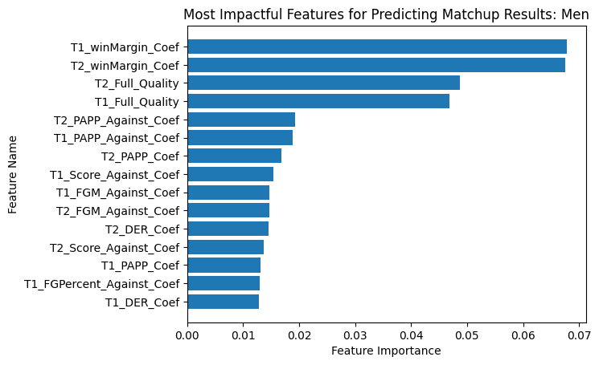

```python
xgbClassifierAdj_feature_importance_m = pd.DataFrame(
    {"feature":X_train_Adj_m.columns, "importance":xgbClassifierAdj_m.feature_importances_}).sort_values(
    by=['importance'], ascending = True).reset_index(drop = True)

xgbClassifierAdj_feature_importance_m = xgbClassifierAdj_feature_importance_m.iloc[-15:]
plt.barh(y=xgbClassifierAdj_feature_importance_m.feature, width=xgbClassifierAdj_feature_importance_m.importance)
plt.xlabel('Feature Importance')
plt.ylabel('Feature Name')
plt.title("Most Impactful Features for Predicting Matchup Results: Men")
plt.show()
```

#### Women's Feature Importance

Similar to the men's model, it is encouraging to see that the Quality Rankings for both Team 1 and Team 2 are both in the top 10 important features.

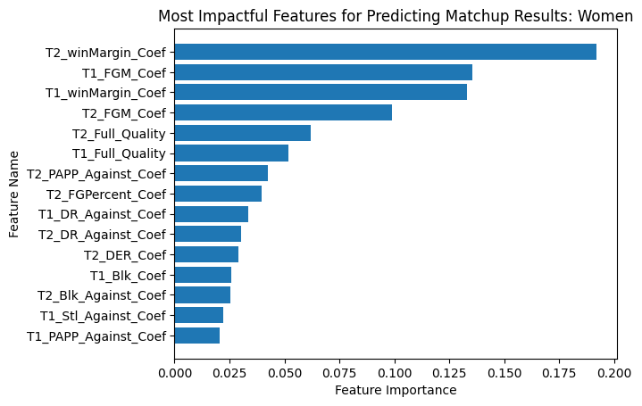

```python
xgbClassifierAdj_feature_importance_w = pd.DataFrame(
    {"feature":X_train_Adj_w.columns, "importance":xgbClassifierAdj_w.feature_importances_}).sort_values(
    by=['importance'], ascending = True).reset_index(drop = True)
xgbClassifierAdj_feature_importance_w = xgbClassifierAdj_feature_importance_w.iloc[-15:]
plt.barh(y=xgbClassifierAdj_feature_importance_w.feature, width=xgbClassifierAdj_feature_importance_w.importance)
plt.xlabel('Feature Importance')
plt.ylabel('Feature Name')
plt.title("Most Impactful Features for Predicting Matchup Results: Women")
plt.show()
```

# Applying the results: Building a bracket with the predicted results

Building a model that performs well in predicting matchup winners is only half of the fun. The most important part in any Data Science project is being able to apply the work to accomplish something bigger!

I will be using this notebook to build my brackets for the 2024 NCAA March Madness Tournament. Stay tuned for an update at the end to analyze the real life performance.

## Prepare 2024 Data

I will be applying the same process outlined throughout the notebook previously to the 2024 specific data. The same features will be generated.

Since all my data was scaled prior to modeling, I will apply the already previously fit scaler objects to the 2024 data to ensure it is scaled on the same scale as the model's data.

One important note that you will see below is that I have introduced an element of simulation to my final output. The output of any model will simply be the predicted probability that Team 1 win's over Team 2. Although I trust my models to produce strong predictions, adding another layer of randomness will help produce even stronger output considering the randomness of the tournament itself.

### Read in 2024 specific Tournament Data

```python
round_slots_m = pd.read_csv('/kaggle/input/march-machine-learning-mania-2024/MNCAATourneySlots.csv')
round_slots_m = round_slots_m[round_slots_m['Season'] == 2024]
round_slots_m = round_slots_m[round_slots_m['Slot'].str.contains('R')] # Filter out First Four

round_slots_w = pd.read_csv('/kaggle/input/march-machine-learning-mania-2024/WNCAATourneySlots.csv')
round_slots_w = round_slots_w[round_slots_w['Season'] == 2024]
round_slots_w = round_slots_w[round_slots_w['Slot'].str.contains('R')] # Filter out First Four
```

```python
sim_seeds = pd.read_csv('/kaggle/input/march-machine-learning-mania-2024/2024_tourney_seeds.csv')
sim_seeds['TeamID'] = sim_seeds['TeamID'].astype(str)
sim_seeds_m = sim_seeds[sim_seeds['Tournament'] == 'M']
sim_seeds_w = sim_seeds[sim_seeds['Tournament'] == 'W']
```

### Subset Datasets for 2024 Season

```python
seeds2024_m = seeds_m[seeds_m.Season == '2024']
seeds2024_w = seeds_w[seeds_w.Season == '2024']

regular_results_detailed2024_m = regular_results_detailed_m[regular_results_detailed_m.Season == 2024]
regular_results_detailed2024_w = regular_results_detailed_w[regular_results_detailed_w.Season == 2024]
```

The below two functions were sourced from LENNART HAUPTS's notebook for turning the previous format's predicted probabilities into a bracket format: https://www.kaggle.com/code/lennarthaupts/simulate-n-brackets.

```python
def prepare_data(seeds, preds):
    # Function preparing the data for the simulation
    seed_dict = seeds.set_index('Seed')['TeamID'].to_dict()
    inverted_seed_dict = {value: key for key, value in seed_dict.items()}
    probas_dict = {}

    for teams, proba in zip(preds['ID'], preds['Pred']):
        team1, team2 = teams[1], teams[2]

        probas_dict.setdefault(team1, {})[team2] = proba
        probas_dict.setdefault(team2, {})[team1] = 1 - proba

    return seed_dict, inverted_seed_dict, probas_dict


def simulate(round_slots, seeds, inverted_seeds, probas, random_values, sim=True):
    '''
    Simulates each round of the tournament.

    Parameters:
    - round_slots: DataFrame containing information on who is playing in each round.
    - seeds (dict): Dictionary mapping seed values to team IDs.
    - inverted_seeds (dict): Dictionary mapping team IDs to seed values.
    - probas (dict): Dictionary containing matchup probabilities.
    - random_values (array-like): Array with precomputed random-values.
    - sim (boolean): Simulates match if True. Chooses team with higher probability as winner otherwise.

    Returns:
    - list: List with winning team IDs for each match.
    - list: List with corresponding slot names for each match.
    '''
    winners = []
    slots = []

    for slot, strong, weak, random_val in zip(round_slots.Slot, round_slots.StrongSeed, round_slots.WeakSeed, random_values):
        team1, team2 = seeds[strong], seeds[weak]

        # Get the probability of team_1 winning
        proba = probas[str(team1)][str(team2)]

        if sim:
            # Randomly determine the winner based on the probability
            winner = team1 if random_val < proba else team2
        else:
            # Determine the winner based on the higher probability
            winner = [team1, team2][np.argmax([proba, 1-proba])]

        # Append the winner and corresponding slot to the lists
        winners.append(winner)
        slots.append(slot)

        seeds[slot] = winner

    # Convert winners to original seeds using the inverted_seeds dictionary
    return [inverted_seeds[w] for w in winners], slots


def run_simulation(brackets=1, seeds=None, preds=None, round_slots=None, sim=True):
    '''
    Runs a simulation of bracket tournaments.

    Parameters:
    - brackets (int): Number of brackets to simulate.
    - seeds (pd.DataFrame): DataFrame containing seed information.
    - preds (pd.DataFrame): DataFrame containing prediction information for each match-up.
    - round_slots (pd.DataFrame): DataFrame containing information about the tournament rounds.
    - sim (boolean): Simulates matches if True. Chooses team with higher probability as winner otherwise.

    Returns:
    - pd.DataFrame: DataFrame with simulation results.
    '''
    # Get relevant data for the simulation
    seed_dict, inverted_seed_dict, probas_dict = prepare_data(seeds, preds)
    # Lists to store simulation results
    results = []
    bracket = []
    slots = []

    # Precompute random-values
    np.random.seed(2024)
    random_values = np.random.random(size=(brackets, len(round_slots)))

    # Iterate through the specified number of brackets
    for b in tqdm(range(1, brackets+1)):
        # Run single simulation
        r, s = simulate(round_slots, seed_dict, inverted_seed_dict, probas_dict, random_values[b-1], sim)

        # Update results
        results.extend(r)
        bracket.extend([b] * len(r))
        slots.extend(s)

    # Create final DataFrame
    result_df = pd.DataFrame({'Bracket': bracket, 'Slot': slots, 'Team': results})

    return result_df
```

```python
def matchupGenerator(seeds_df):
    results = []

    for i in list(set(seeds_df.Season.values)):

        matchups = list(itertools.combinations(np.array(seeds_df[seeds_df.Season == i].TeamID), 2))
        matchups = pd.DataFrame(matchups)
        matchups['Season'] = i
        matchups.columns = ['T1_TeamID', 'T2_TeamID', 'Season']

        matchups['IDLow'] = np.where(matchups['T1_TeamID'] < matchups['T2_TeamID'], matchups['T1_TeamID'], matchups['T2_TeamID'])
        matchups['IDHigh'] = np.where(matchups['T1_TeamID'] > matchups['T2_TeamID'], matchups['T1_TeamID'], matchups['T2_TeamID'])

        matchups['ID'] = matchups["Season"].astype(str) + '_' + matchups["IDLow"].astype(str) + '_' +matchups["IDHigh"].astype(str)
        matchups['T1_TeamID'] = matchups['IDLow']
        matchups['T2_TeamID'] = matchups['IDHigh']
        matchups.drop(['IDLow', 'IDHigh'], axis = 1, inplace = True)

        matchups['Season'] = matchups['Season'].astype(str)

        results.extend(matchups.values.tolist())

    results = pd.DataFrame(results)
    results.columns = ['T1_TeamID', 'T2_TeamID', 'Season', 'ID']

    return results
```

## Building 2024 Brackets for Mens Tournament

```python
regular_results_modified_2024_m = prepare_data_modified(regular_results_detailed2024_m)
```

```python
team_quality_2024_m = team_quality(regular_results_modified_2024_m)
```

```python
dimensions = ['Score','FGM','FGA','FGM3','FGA3','FTM','FTA','OR','DR',
              'Ast','TO','Stl','Blk','PF','Possessions', 'OER',
              'DER','PAPP','FGPercent','FG3Percent','winMargin']
adjusted_rankings_2024_m = run_adjusted_rankings(regular_results_modified_2024_m, dimensions)
adjusted_rankings_2024_m.drop(['winMargin_Against_Coef', 'DER_Against_Coef', 'OER_Against_Coef'], axis = 1, inplace = True)
```

```python
adjusted_rankings_t1_2024_m = adjusted_rankings_2024_m.copy(deep = True).add_prefix("T1_")
adjusted_rankings_t1_2024_m.rename(columns={'T1_TeamID': 'TeamID'}, inplace=True)
adjusted_rankings_t1_2024_m.rename(columns={'T1_Season': 'Season'}, inplace=True)


adjusted_rankings_t2_2024_m = adjusted_rankings_2024_m.copy(deep = True).add_prefix("T2_")
adjusted_rankings_t2_2024_m.rename(columns={'T2_TeamID': 'TeamID'}, inplace=True)
adjusted_rankings_t2_2024_m.rename(columns={'T2_Season': 'Season'}, inplace=True)
```

```python
matchups2024_m = matchupGenerator(seeds2024_m)
```

```python
matchups2024_Adj_m = matchups2024_m.copy(deep = True)
```

```python
matchups2024_Adj_m = matchups2024_Adj_m.merge(adjusted_rankings_t1_2024_m,
                               how='left',
                               left_on = ['Season','T1_TeamID'],
                               right_on =['Season','TeamID'],
                               sort=False)
matchups2024_Adj_m.drop(['TeamID'], axis = 1, inplace = True)

matchups2024_Adj_m = matchups2024_Adj_m.merge(adjusted_rankings_t2_2024_m,
                               how='left',
                               left_on = ['Season','T2_TeamID'],
                               right_on =['Season','TeamID'],
                               sort=False)
matchups2024_Adj_m.drop(['TeamID'], axis = 1, inplace = True)
```

```python
matchups2024_Adj_m = matchups2024_Adj_m.merge(team_quality_2024_m[['TeamID', 'Season', 'quality']],
                               how='left',
                               left_on = ['Season','T1_TeamID'],
                               right_on =['Season','TeamID'],
                               sort=False)
matchups2024_Adj_m.rename(columns={'quality': 'T1_Full_Quality'}, inplace=True)
matchups2024_Adj_m.drop(['TeamID'], axis = 1, inplace = True)
matchups2024_Adj_m.head()


matchups2024_Adj_m = matchups2024_Adj_m.merge(team_quality_2024_m[['TeamID', 'Season', 'quality']],
                               how='left',
                               left_on = ['Season','T2_TeamID'],
                               right_on =['Season','TeamID'],
                               sort=False)
matchups2024_Adj_m.rename(columns={'quality': 'T2_Full_Quality'}, inplace=True)
matchups2024_Adj_m.drop(['TeamID'], axis = 1, inplace = True)
```

```python
X_preds_Adj_2024_scaled_m = matchups2024_Adj_m.drop(['Season', 'T1_TeamID', 'T2_TeamID', 'ID'], axis = 1)
X_preds_Adj_2024_scaled_m = scaler_Adj_m.transform(X_preds_Adj_2024_scaled_m)
```

```python
Adj_2024_preds_m = pd.DataFrame(xgbClassifierAdj_m.predict_proba(X_preds_Adj_2024_scaled_m)[:,1])
Adj_2024_preds_m.columns = ['Pred']
Adj_2024_preds_m['ID'] = matchups2024_Adj_m['ID']
Adj_2024_preds_m['ID'] = Adj_2024_preds_m['ID'].str.split('_')
```

#### Simulating Brackets

Using the predicted probabilities from the final XGBoost model, the below will generate a "bracket" of sorts for the men's tournament by combining the results of 100,000 simulated brackets built off of the XGBoost model.

```python
n_brackets = 100000
result_sim_m= run_simulation(brackets=n_brackets, seeds=sim_seeds_m, preds=Adj_2024_preds_m, round_slots=round_slots_m, sim=True)
result_sim_m['Tournament'] = 'M'
submission_m = result_sim_m.copy(deep = True)
```

```python
result_sim_m = result_sim_m.merge(sim_seeds_m[['Seed', 'TeamID']], left_on = "Team", right_on = "Seed")
```

```python
result_sim_m = result_sim_m.merge(team_keys_m[['TeamID', 'TeamName']], on = 'TeamID')
result_sim_m['Slot'] = result_sim_m['Slot'].str.replace('W', ' East ')
result_sim_m['Slot'] = result_sim_m['Slot'].str.replace('X', ' West ')
result_sim_m['Slot'] = result_sim_m['Slot'].str.replace('Y', ' Midwest ')
result_sim_m['Slot'] = result_sim_m['Slot'].str.replace('Z', ' South ')
```

```python
result_sim_pivot_m = pd.pivot_table(result_sim_m, values=["Tournament"],
                       index=["Slot"], columns=["TeamName"],
                       aggfunc=len, margins=True,
                       dropna=True, fill_value=None)
result_sim_pivot_m = (np.round(result_sim_pivot_m.div(result_sim_pivot_m.iloc[:,-1], axis=0)*100, decimals = 2)).astype(str)+"%"
result_sim_pivot_m = result_sim_pivot_m.replace("nan%", '')
```

## Mens 2024 Bracket Predictions

How should this be interpretted? Every "slot" is a game that will be played by a certain combination of teams. Each team only has one possible path to the championship, and their opponents are limited based on the structure/path of the other teams in the bracket.

The "R1" games are all pretty self explanatory, they correspond to each of the 8 games played within each region/division of the tournament.

- R1 East 1 slot is the game played between the East #1 seed and the #16 seed.
- R1 East 2 slot is the game played between the East #2 seed and the #15 seed.
- Etc.

"R2" slots correspond to the second round of the tournament, also known as the round of 32, where each division has 4 games played. The way the brackets are built, the top seeds will play winner of the highest game slot from the previous round.

- R2 East 1 slot is the matchup between the winner of R1 East 1 and R1 East 8.
- R2 East 2 slot is the matchup between the winner of R1 East 2 and R1 East 7.
- Etc.

"R3" slots correspond to the third round of the tournament, also known as the Sweet Sixteen where each division has 2 games played. Similar to the previous logic, the winner of the top slot in R2 will play the winner of the worst slot in R2 as the R3 matchup.

- R3 East 1 slot is the matchup between R2 East 1 and R2 East 4.
- R3 East 2 slot is the matchup between R2 East 2 and R2 East 3.

"R4" slots correspond to the fourth round of the tournament, also known as the Elite 8 where each division has 1 games played. Similar to the previous logic, the winner of the top slot in R3 will play the winner of the worst slot in R3 as the R4 matchup.

- R4 East 1 slot is the matchup between R3 East 1 and R3 East 2.

"R5" slots correspond to the fifth round of the tournament, also known as the Final Four. This round comprises of the final team in each division. In 2024, this is the matchup between the East champion and the West Champion, and the matchup between the South Champion and the Midwest champion.

"R6" is the final championship game.

```python
result_sim_pivot_m
```

| TeamName Slot | Tournament Akron | Tournament Alabama | Tournament Arizona | Tournament Auburn | Tournament BYU | Tournament Baylor | Tournament Clemson | Tournament Col Charleston | Tournament Colgate | Tournament Colorado | Tournament Colorado St | Tournament Connecticut | Tournament Creighton | Tournament Dayton | Tournament Drake | Tournament Duke | Tournament Duquesne | Tournament FL Atlantic | Tournament Florida | Tournament Gonzaga | Tournament Grambling | Tournament Grand Canyon | Tournament Houston | Tournament Illinois | Tournament Iowa St | Tournament James Madison | Tournament Kansas | Tournament Kentucky | Tournament Long Beach St | … |
| --- | --- | --- | --- | --- | --- | --- | --- | --- | --- | --- | --- | --- | --- | --- | --- | --- | --- | --- | --- | --- | --- | --- | --- | --- | --- | --- | --- | --- | --- | --- |
| R1 East 1 |  |  |  |  |  |  |  |  |  |  |  | 85.46% |  |  |  |  |  |  |  |  |  |  |  |  |  |  |  |  |  | … |
| R1 East 2 |  |  |  |  |  |  |  |  |  |  |  |  |  |  |  |  |  |  |  |  |  |  |  |  | 85.95% |  |  |  |  | … |
| R1 East 3 |  |  |  |  |  |  |  |  |  |  |  |  |  |  |  |  |  |  |  |  |  |  |  | 72.94% |  |  |  |  |  | … |
| R1 East 4 |  |  |  | 85.41% |  |  |  |  |  |  |  |  |  |  |  |  |  |  |  |  |  |  |  |  |  |  |  |  |  | … |
| R1 East 5 |  |  |  |  |  |  |  |  |  |  |  |  |  |  |  |  |  |  |  |  |  |  |  |  |  |  |  |  |  | … |
| R1 East 6 |  |  |  |  | 67.27% |  |  |  |  |  |  |  |  |  |  |  | 32.73% |  |  |  |  |  |  |  |  |  |  |  |  | … |
| R1 East 7 |  |  |  |  |  |  |  |  |  |  |  |  |  |  | 41.83% |  |  |  |  |  |  |  |  |  |  |  |  |  |  | … |
| R1 East 8 |  |  |  |  |  |  |  |  |  |  |  |  |  |  |  |  |  | 52.72% |  |  |  |  |  |  |  |  |  |  |  | … |
| R1 Midwest 1 |  |  |  |  |  |  |  |  |  |  |  |  |  |  |  |  |  |  |  |  | 14.36% |  |  |  |  |  |  |  |  | … |
| R1 Midwest 2 |  |  |  |  |  |  |  |  |  |  |  |  |  |  |  |  |  |  |  |  |  |  |  |  |  |  |  |  |  | … |
| R1 Midwest 3 | 20.73% |  |  |  |  |  |  |  |  |  |  |  | 79.27% |  |  |  |  |  |  |  |  |  |  |  |  |  |  |  |  | … |
| R1 Midwest 4 |  |  |  |  |  |  |  |  |  |  |  |  |  |  |  |  |  |  |  |  |  |  |  |  |  |  | 73.1% |  |  | … |
| R1 Midwest 5 |  |  |  |  |  |  |  |  |  |  |  |  |  |  |  |  |  |  |  | 60.61% |  |  |  |  |  |  |  |  |  | … |
| R1 Midwest 6 |  |  |  |  |  |  |  |  |  |  |  |  |  |  |  |  |  |  |  |  |  |  |  |  |  |  |  |  |  | … |
| R1 Midwest 7 |  |  |  |  |  |  |  |  |  |  | 42.47% |  |  |  |  |  |  |  |  |  |  |  |  |  |  |  |  |  |  | … |
| R1 Midwest 8 |  |  |  |  |  |  |  |  |  |  |  |  |  |  |  |  |  |  |  |  |  |  |  |  |  |  |  |  |  | … |
| R1 South 1 |  |  |  |  |  |  |  |  |  |  |  |  |  |  |  |  |  |  |  |  |  |  | 84.86% |  |  |  |  |  |  | … |
| R1 South 2 |  |  |  |  |  |  |  |  |  |  |  |  |  |  |  |  |  |  |  |  |  |  |  |  |  |  |  |  |  | … |
| R1 South 3 |  |  |  |  |  |  |  |  |  |  |  |  |  |  |  |  |  |  |  |  |  |  |  |  |  |  |  | 66.02% |  | … |
| R1 South 4 |  |  |  |  |  |  |  |  |  |  |  |  |  |  |  | 76.89% |  |  |  |  |  |  |  |  |  |  |  |  |  | … |
| R1 South 5 |  |  |  |  |  |  |  |  |  |  |  |  |  |  |  |  |  |  |  |  |  |  |  |  |  | 45.18% |  |  |  | … |
| R1 South 6 |  |  |  |  |  |  |  |  |  |  |  |  |  |  |  |  |  |  |  |  |  |  |  |  |  |  |  |  |  | … |
| R1 South 7 |  |  |  |  |  |  |  |  |  | 53.52% |  |  |  |  |  |  |  |  | 46.48% |  |  |  |  |  |  |  |  |  |  | … |
| R1 South 8 |  |  |  |  |  |  |  |  |  |  |  |  |  |  |  |  |  |  |  |  |  |  |  |  |  |  |  |  |  | … |
| R1 West 1 |  |  |  |  |  |  |  |  |  |  |  |  |  |  |  |  |  |  |  |  |  |  |  |  |  |  |  |  |  | … |
| R1 West 2 |  |  | 82.3% |  |  |  |  |  |  |  |  |  |  |  |  |  |  |  |  |  |  |  |  |  |  |  |  |  | 17.7% | … |
| R1 West 3 |  |  |  |  |  | 80.56% |  |  | 19.44% |  |  |  |  |  |  |  |  |  |  |  |  |  |  |  |  |  |  |  |  | … |
| R1 West 4 |  | 76.54% |  |  |  |  |  | 23.46% |  |  |  |  |  |  |  |  |  |  |  |  |  |  |  |  |  |  |  |  |  | … |
| R1 West 5 |  |  |  |  |  |  |  |  |  |  |  |  |  |  |  |  |  |  |  |  |  | 41.37% |  |  |  |  |  |  |  | … |
| R1 West 6 |  |  |  |  |  |  | 42.39% |  |  |  |  |  |  |  |  |  |  |  |  |  |  |  |  |  |  |  |  |  |  | … |
| R1 West 7 |  |  |  |  |  |  |  |  |  |  |  |  |  | 53.87% |  |  |  |  |  |  |  |  |  |  |  |  |  |  |  | … |
| R1 West 8 |  |  |  |  |  |  |  |  |  |  |  |  |  |  |  |  |  |  |  |  |  |  |  |  |  |  |  |  |  | … |
| R2 East 1 |  |  |  |  |  |  |  |  |  |  |  | 63.66% |  |  |  |  |  | 14.72% |  |  |  |  |  |  |  |  |  |  |  | … |
| R2 East 2 |  |  |  |  |  |  |  |  |  |  |  |  |  |  | 11.54% |  |  |  |  |  |  |  |  |  | 59.86% |  |  |  |  | … |
| R2 East 3 |  |  |  |  | 39.58% |  |  |  |  |  |  |  |  |  |  |  | 15.22% |  |  |  |  |  |  | 36.43% |  |  |  |  |  | … |
| R2 East 4 |  |  |  | 64.95% |  |  |  |  |  |  |  |  |  |  |  |  |  |  |  |  |  |  |  |  |  |  |  |  |  | … |
| R2 Midwest 1 |  |  |  |  |  |  |  |  |  |  |  |  |  |  |  |  |  |  |  |  | 4.17% |  |  |  |  |  |  |  |  | … |
| R2 Midwest 2 |  |  |  |  |  |  |  |  |  |  | 14.28% |  |  |  |  |  |  |  |  |  |  |  |  |  |  |  |  |  |  | … |
| R2 Midwest 3 | 6.4% |  |  |  |  |  |  |  |  |  |  |  | 41.42% |  |  |  |  |  |  |  |  |  |  |  |  |  |  |  |  | … |
| R2 Midwest 4 |  |  |  |  |  |  |  |  |  |  |  |  |  |  |  |  |  |  |  | 28.68% |  |  |  |  |  |  | 43.13% |  |  | … |
| R2 South 1 |  |  |  |  |  |  |  |  |  |  |  |  |  |  |  |  |  |  |  |  |  |  | 66.55% |  |  |  |  |  |  | … |
| R2 South 2 |  |  |  |  |  |  |  |  |  | 17.09% |  |  |  |  |  |  |  |  | 13.58% |  |  |  |  |  |  |  |  |  |  | … |
| R2 South 3 |  |  |  |  |  |  |  |  |  |  |  |  |  |  |  |  |  |  |  |  |  |  |  |  |  |  |  | 29.05% |  | … |
| R2 South 4 |  |  |  |  |  |  |  |  |  |  |  |  |  |  |  | 51.55% |  |  |  |  |  |  |  |  |  | 13.57% |  |  |  | … |
| R2 West 1 |  |  |  |  |  |  |  |  |  |  |  |  |  |  |  |  |  |  |  |  |  |  |  |  |  |  |  |  |  | … |
| R2 West 2 |  |  | 60.5% |  |  |  |  |  |  |  |  |  |  | 17.14% |  |  |  |  |  |  |  |  |  |  |  |  |  |  | 5.52% | … |
| R2 West 3 |  |  |  |  |  | 48.07% | 21.71% |  | 5.66% |  |  |  |  |  |  |  |  |  |  |  |  |  |  |  |  |  |  |  |  | … |
| R2 West 4 |  | 33.96% |  |  |  |  |  | 7.69% |  |  |  |  |  |  |  |  |  |  |  |  |  | 21.84% |  |  |  |  |  |  |  | … |
| R3 East 1 |  |  |  | 35.3% |  |  |  |  |  |  |  | 40.19% |  |  |  |  |  | 4.75% |  |  |  |  |  |  |  |  |  |  |  | … |
| R3 East 2 |  |  |  |  | 21.7% |  |  |  |  |  |  |  |  |  | 4.51% |  | 5.3% |  |  |  |  |  |  | 18.89% | 33.61% |  |  |  |  | … |
| R3 Midwest 1 |  |  |  |  |  |  |  |  |  |  |  |  |  |  |  |  |  |  |  | 10.36% | 1.14% |  |  |  |  |  | 17.09% |  |  | … |
| R3 Midwest 2 | 1.47% |  |  |  |  |  |  |  |  |  | 6.91% |  | 20.06% |  |  |  |  |  |  |  |  |  |  |  |  |  |  |  |  | … |
| R3 South 1 |  |  |  |  |  |  |  |  |  |  |  |  |  |  |  | 23.48% |  |  |  |  |  |  | 45.63% |  |  | 4.36% |  |  |  | … |
| R3 South 2 |  |  |  |  |  |  |  |  |  | 8.99% |  |  |  |  |  |  |  |  | 6.3% |  |  |  |  |  |  |  |  | 11.75% |  | … |
| R3 West 1 |  | 13.58% |  |  |  |  |  | 1.56% |  |  |  |  |  |  |  |  |  |  |  |  |  | 7.55% |  |  |  |  |  |  |  | … |
| R3 West 2 |  |  | 38.82% |  |  | 24.34% | 9.35% |  | 1.29% |  |  |  |  | 7.65% |  |  |  |  |  |  |  |  |  |  |  |  |  |  | 1.52% | … |
| R4 East 1 |  |  |  | 22.55% | 8.93% |  |  |  |  |  |  | 27.3% |  |  | 1.24% |  | 1.43% | 1.58% |  |  |  |  |  | 7.89% | 15.21% |  |  |  |  | … |
| R4 Midwest 1 | 0.31% |  |  |  |  |  |  |  |  |  | 2.47% |  | 8.89% |  |  |  |  |  |  | 4.57% | 0.24% |  |  |  |  |  | 8.12% |  |  | … |
| R4 South 1 |  |  |  |  |  |  |  |  |  | 3.16% |  |  |  |  |  | 13.21% |  |  | 1.96% |  |  |  | 30.76% |  |  | 1.63% |  | 3.98% |  | … |
| R4 West 1 |  | 6.55% | 20.63% |  |  | 12.09% | 3.99% | 0.39% | 0.27% |  |  |  |  | 3.13% |  |  |  |  |  |  |  | 2.66% |  |  |  |  |  |  | 0.38% | … |
| R5 East West |  | 2.5% | 9.12% | 15.0% | 4.66% | 4.98% | 1.48% | 0.07% | 0.04% |  |  | 18.69% |  | 0.94% | 0.39% |  | 0.49% | 0.58% |  |  |  | 0.82% |  | 4.09% | 8.66% |  |  |  | 0.06% | … |
| R5 Midwest South | 0.06% |  |  |  |  |  |  |  |  | 1.05% | 0.82% |  | 3.98% |  |  | 6.26% |  |  | 0.58% | 1.8% | 0.04% |  | 17.73% |  |  | 0.49% | 3.51% | 1.39% |  | … |
| R6CH | 0.01% | 0.95% | 4.25% | 8.54% | 2.06% | 2.06% | 0.55% | 0.01% | 0.01% | 0.33% | 0.3% | 11.82% | 1.76% | 0.28% | 0.1% | 2.98% | 0.16% | 0.17% | 0.17% | 0.62% | 0.01% | 0.24% | 10.02% | 1.84% | 4.03% | 0.12% | 1.46% | 0.45% | 0.01% | … |
| All | 0.46% | 2.13% | 3.42% | 3.68% | 2.29% | 2.73% | 1.26% | 0.53% | 0.42% | 1.34% | 1.07% | 3.92% | 2.47% | 1.32% | 0.95% | 2.77% | 0.88% | 1.18% | 1.1% | 1.69% | 0.32% | 1.18% | 4.06% | 2.26% | 3.29% | 1.04% | 2.32% | 1.79% | 0.4% | … |

#### Men's bracket built off of the above simulation:

[figure not shown]

**Scoring:**

- Round 1 = 23/32 correct
- Round 2 = 11/16 correct
- Round 3 = 3 / 8 correct
- Round 4 = 2 / 4 correct
- Round 5 = 2 / 2 correct
- Round 6 = 0 / 1 correct

**Following ESPN's scoring system of:**

- Round 1 = 10 points per correct
- Round 2 = 20 points per correct
- Round 3 = 40 points per correct
- Round 4 = 80 points per correct
- Round 5 = 160 points per correct
- Round 6 = 320 points per correct

**Total score of:** 230 + 220 + 120 + 160 + 320 + 0 = **1050**

## Building 2024 Brackets for Womens Tournament

```python
regular_results_modified_2024_w = prepare_data_modified(regular_results_detailed2024_w)
```

```python
team_quality_2024_w = team_quality(regular_results_modified_2024_w)
```

```python
dimensions = ['Score','FGM','FGA','FGM3','FGA3','FTM','FTA','OR',
              'DR','Ast','TO','Stl','Blk','PF','Possessions',
              'OER','DER','PAPP','FGPercent','FG3Percent','winMargin']
adjusted_rankings_2024_w = run_adjusted_rankings(regular_results_modified_2024_w, dimensions)
adjusted_rankings_2024_w.drop(['winMargin_Against_Coef', 'DER_Against_Coef', 'OER_Against_Coef'], axis = 1, inplace = True)
```

```python
adjusted_rankings_t1_2024_w = adjusted_rankings_2024_w.copy(deep = True).add_prefix("T1_")
adjusted_rankings_t1_2024_w.rename(columns={'T1_TeamID': 'TeamID'}, inplace=True)
adjusted_rankings_t1_2024_w.rename(columns={'T1_Season': 'Season'}, inplace=True)


adjusted_rankings_t2_2024_w = adjusted_rankings_2024_w.copy(deep = True).add_prefix("T2_")
adjusted_rankings_t2_2024_w.rename(columns={'T2_TeamID': 'TeamID'}, inplace=True)
adjusted_rankings_t2_2024_w.rename(columns={'T2_Season': 'Season'}, inplace=True)
```

```python
matchups2024_w = matchupGenerator(seeds2024_w)
```

```python
matchups2024_Adj_w = matchups2024_w.copy(deep = True)
```

```python
matchups2024_Adj_w = matchups2024_Adj_w.merge(adjusted_rankings_t1_2024_w,
                               how='left',
                               left_on = ['Season','T1_TeamID'],
                               right_on =['Season','TeamID'],
                               sort=False)
matchups2024_Adj_w.drop(['TeamID'], axis = 1, inplace = True)

matchups2024_Adj_w = matchups2024_Adj_w.merge(adjusted_rankings_t2_2024_w,
                               how='left',
                               left_on = ['Season','T2_TeamID'],
                               right_on =['Season','TeamID'],
                               sort=False)
matchups2024_Adj_w.drop(['TeamID'], axis = 1, inplace = True)
```

```python
matchups2024_Adj_w = matchups2024_Adj_w.merge(team_quality_2024_w[['TeamID', 'Season', 'quality']],
                               how='left',
                               left_on = ['Season','T1_TeamID'],
                               right_on =['Season','TeamID'],
                               sort=False)
matchups2024_Adj_w.rename(columns={'quality': 'T1_Full_Quality'}, inplace=True)
matchups2024_Adj_w.drop(['TeamID'], axis = 1, inplace = True)
matchups2024_Adj_w.head()


matchups2024_Adj_w = matchups2024_Adj_w.merge(team_quality_2024_w[['TeamID', 'Season', 'quality']],
                               how='left',
                               left_on = ['Season','T2_TeamID'],
                               right_on =['Season','TeamID'],
                               sort=False)
matchups2024_Adj_w.rename(columns={'quality': 'T2_Full_Quality'}, inplace=True)
matchups2024_Adj_w.drop(['TeamID'], axis = 1, inplace = True)
```

```python
X_preds_Adj_2024_scaled_w = matchups2024_Adj_w.drop(['Season', 'T1_TeamID', 'T2_TeamID', 'ID'], axis = 1)
X_preds_Adj_2024_scaled_w = scaler_Adj_w.transform(X_preds_Adj_2024_scaled_w)
```

```python
Adj_2024_preds_w = pd.DataFrame(xgbClassifierAdj_w.predict_proba(X_preds_Adj_2024_scaled_w)[:,1])
Adj_2024_preds_w.columns = ['Pred']
Adj_2024_preds_w['ID'] = matchups2024_Adj_w['ID']
Adj_2024_preds_w['ID'] = Adj_2024_preds_w['ID'].str.split('_')
```

#### Simulated Brackets

```python
n_brackets = 100000
result_sim_w= run_simulation(brackets=n_brackets, seeds=sim_seeds_w, preds=Adj_2024_preds_w, round_slots=round_slots_w, sim=True)
result_sim_w['Tournament'] = 'W'
submission_w = result_sim_w.copy(deep = True)
```

```python
result_sim_w = result_sim_w.merge(sim_seeds_w[['Seed', 'TeamID']], left_on = "Team", right_on = "Seed")
```

```python
result_sim_w = result_sim_w.merge(team_keys_w[['TeamID', 'TeamName']], on = 'TeamID')
result_sim_w['Slot'] = result_sim_w['Slot'].str.replace('W', ' Albany1 ')
result_sim_w['Slot'] = result_sim_w['Slot'].str.replace('X', ' Portland4 ')
result_sim_w['Slot'] = result_sim_w['Slot'].str.replace('Y', ' Albany2 ')
result_sim_w['Slot'] = result_sim_w['Slot'].str.replace('Z', ' Portland3 ')
```

```python
result_sim_pivot_w = pd.pivot_table(result_sim_w, values=["Tournament"],
                       index=["Slot"], columns=["TeamName"],
                       aggfunc=len, margins=True,
                       dropna=True, fill_value=None)
result_sim_pivot_w = (np.round(result_sim_pivot_w.div(result_sim_pivot_w.iloc[:,-1], axis=0)*100, decimals = 2)).astype(str)+"%"
result_sim_pivot_w = result_sim_pivot_w.replace("nan%", '')
```

## Womens 2024 Bracket Predictions

How should this be interpretted? Every "slot" is a game that will be played by a certain combination of teams. Each team only has one possible path to the championship, and their opponents are limited based on the structure/path of the other teams in the bracket.

Each slot has two or more percentages in the pivot table that correspond to the percentage of the 100,000 brackets that have that team as the winner of that slot. The team with the highest percentage is the team we would build our final bracket with as the winner for that slot. For example:

The "R1" games are all pretty self explanatory, they correspond to each of the 8 games played within each region/division of the tournament.

- R1 Albany1 1 slot is the game played between the Albany1 #1 seed and the #16 seed.
- R1 Albany1 2 slot is the game played between the Albany1 #2 seed and the #15 seed.
- Etc.

"R2" slots correspond to the second round of the tournament, also known as the round of 32, where each division has 4 games played. The way the brackets are built, the top seeds will play winner of the highest game slot from the previous round.

- R2 Albany1 1 slot is the matchup between the winner of R1 Albany1 1 and R1 Albany1 8.
- R2 Albany1 2 slot is the matchup between the winner of R1 Albany1 2 and R1 Albany1 7.
- Etc.

"R3" slots correspond to the third round of the tournament, also known as the Sweet Sixteen where each division has 2 games played. Similar to the previous logic, the winner of the top slot in R2 will play the winner of the worst slot in R2 as the R3 matchup.

- R3 Albany1 1 slot is the matchup between R2 Albany1 1 and R2 Albany1 4.
- R3 Albany1 2 slot is the matchup between R2 Albany1 2 and R2 Albany1 3.

"R4" slots correspond to the fourth round of the tournament, also known as the Elite 8 where each division has 1 games played. Similar to the previous logic, the winner of the top slot in R3 will play the winner of the worst slot in R3 as the R4 matchup.

- R4 Albany1 1 slot is the matchup between R3 Albany1 1 and R3 Albany1 2.

"R6" is the final championship game.

```python
result_sim_pivot_w
```

| TeamName Slot | Tournament Alabama | Tournament Arizona | Tournament Baylor | Tournament Cal Baptist | Tournament Chattanooga | Tournament Colorado | Tournament Columbia | Tournament Connecticut | Tournament Creighton | Tournament Drake | Tournament Drexel | Tournament Duke | Tournament E Washington | Tournament FL Gulf Coast | Tournament Fairfield | Tournament Florida St | Tournament Gonzaga | Tournament Holy Cross | Tournament Indiana | Tournament Iowa | Tournament Iowa St | Tournament Jackson St | Tournament Kansas | Tournament Kansas St | Tournament Kent | Tournament LSU | Tournament Louisville | Tournament MTSU | Tournament Maine | … |
| --- | --- | --- | --- | --- | --- | --- | --- | --- | --- | --- | --- | --- | --- | --- | --- | --- | --- | --- | --- | --- | --- | --- | --- | --- | --- | --- | --- | --- | --- | --- |
| R1 Albany1 1 |  |  |  |  |  |  |  |  |  |  |  |  |  |  |  |  |  |  |  |  |  |  |  |  |  |  |  |  |  | … |
| R1 Albany1 2 |  |  |  |  |  |  |  |  |  |  |  |  |  |  |  |  |  |  |  |  |  |  |  |  | 10.48% |  |  |  |  | … |
| R1 Albany1 3 |  |  |  |  |  |  |  |  |  |  |  |  | 9.1% |  |  |  |  |  |  |  |  |  |  |  |  |  |  |  |  | … |
| R1 Albany1 4 |  |  |  |  |  |  |  |  |  |  |  |  |  |  | 10.38% |  |  |  | 89.62% |  |  |  |  |  |  |  |  |  |  | … |
| R1 Albany1 5 |  |  |  |  |  |  |  |  |  |  |  |  |  | 28.02% |  |  |  |  |  |  |  |  |  |  |  |  |  |  |  | … |
| R1 Albany1 6 |  |  |  |  |  |  |  |  |  |  |  |  |  |  |  |  |  |  |  |  |  |  |  |  |  |  |  |  |  | … |
| R1 Albany1 7 |  |  |  |  |  |  |  |  |  |  |  |  |  |  |  |  |  |  |  |  |  |  |  |  |  |  |  |  |  | … |
| R1 Albany1 8 |  |  |  |  |  |  |  |  |  |  |  |  |  |  |  |  |  |  |  |  |  |  |  |  |  |  |  |  |  | … |
| R1 Albany2 1 |  |  |  |  |  |  |  |  |  |  |  |  |  |  |  |  |  | 10.45% |  | 89.55% |  |  |  |  |  |  |  |  |  | … |
| R1 Albany2 2 |  |  |  | 6.69% |  |  |  |  |  |  |  |  |  |  |  |  |  |  |  |  |  |  |  |  |  |  |  |  |  | … |
| R1 Albany2 3 |  |  |  |  |  |  |  |  |  |  |  |  |  |  |  |  |  |  |  |  |  |  |  |  |  | 92.27% |  |  |  | … |
| R1 Albany2 4 |  |  |  |  |  |  |  |  |  |  |  |  |  |  |  |  |  |  |  |  |  |  |  | 87.94% |  |  |  |  |  | … |
| R1 Albany2 5 |  |  |  |  |  | 89.88% |  |  |  | 10.12% |  |  |  |  |  |  |  |  |  |  |  |  |  |  |  |  |  |  |  | … |
| R1 Albany2 6 |  |  |  |  |  |  |  |  |  |  |  |  |  |  |  |  |  |  |  |  |  |  |  |  |  |  | 77.72% | 22.28% |  | … |
| R1 Albany2 7 |  |  |  |  |  |  |  |  | 68.52% |  |  |  |  |  |  |  |  |  |  |  |  |  |  |  |  |  |  |  |  | … |
| R1 Albany2 8 |  |  |  |  |  |  |  |  |  |  |  |  |  |  |  |  |  |  |  |  |  |  |  |  |  |  |  |  |  | … |
| R1 Portland3 1 |  |  |  |  |  |  |  |  |  |  |  |  |  |  |  |  |  |  |  |  |  |  |  |  |  |  |  |  |  | … |
| R1 Portland3 2 |  |  |  |  |  |  |  |  |  |  |  |  |  |  |  |  |  |  |  |  |  |  |  |  |  |  |  |  | 9.01% | … |
| R1 Portland3 3 |  |  |  |  |  |  |  | 93.96% |  |  |  |  |  |  |  |  |  |  |  |  |  | 6.04% |  |  |  |  |  |  |  | … |
| R1 Portland3 4 |  |  |  |  |  |  |  |  |  |  |  |  |  |  |  |  |  |  |  |  |  |  |  |  |  |  |  |  |  | … |
| R1 Portland3 5 |  |  | 84.84% |  |  |  | 15.16% |  |  |  |  |  |  |  |  |  |  |  |  |  |  |  |  |  |  |  |  |  |  | … |
| R1 Portland3 6 |  | 56.72% |  |  |  |  |  |  |  |  |  |  |  |  |  |  |  |  |  |  |  |  |  |  |  |  |  |  |  | … |
| R1 Portland3 7 |  |  |  |  |  |  |  |  |  |  |  | 87.2% |  |  |  |  |  |  |  |  |  |  |  |  |  |  |  |  |  | … |
| R1 Portland3 8 |  |  |  |  |  |  |  |  |  |  |  |  |  |  |  |  |  |  |  |  |  |  | 58.24% |  |  |  |  |  |  | … |
| R1 Portland4 1 |  |  |  |  |  |  |  |  |  |  | 6.04% |  |  |  |  |  |  |  |  |  |  |  |  |  |  |  |  |  |  | … |
| R1 Portland4 2 |  |  |  |  |  |  |  |  |  |  |  |  |  |  |  |  |  |  |  |  |  |  |  |  |  |  |  |  |  | … |
| R1 Portland4 3 |  |  |  |  | 9.02% |  |  |  |  |  |  |  |  |  |  |  |  |  |  |  |  |  |  |  |  |  |  |  |  | … |
| R1 Portland4 4 |  |  |  |  |  |  |  |  |  |  |  |  |  |  |  |  | 92.12% |  |  |  |  |  |  |  |  |  |  |  |  | … |
| R1 Portland4 5 |  |  |  |  |  |  |  |  |  |  |  |  |  |  |  |  |  |  |  |  |  |  |  |  |  |  |  |  |  | … |
| R1 Portland4 6 |  |  |  |  |  |  |  |  |  |  |  |  |  |  |  |  |  |  |  |  |  |  |  |  |  |  |  |  |  | … |
| R1 Portland4 7 |  |  |  |  |  |  |  |  |  |  |  |  |  |  |  |  |  |  |  |  | 56.43% |  |  |  |  |  |  |  |  | … |
| R1 Portland4 8 | 46.17% |  |  |  |  |  |  |  |  |  |  |  |  |  |  | 53.83% |  |  |  |  |  |  |  |  |  |  |  |  |  | … |
| R2 Albany1 1 |  |  |  |  |  |  |  |  |  |  |  |  |  |  |  |  |  |  |  |  |  |  |  |  |  |  |  |  |  | … |
| R2 Albany1 2 |  |  |  |  |  |  |  |  |  |  |  |  |  |  |  |  |  |  |  |  |  |  |  |  | 2.23% |  |  |  |  | … |
| R2 Albany1 3 |  |  |  |  |  |  |  |  |  |  |  |  | 1.54% |  |  |  |  |  |  |  |  |  |  |  |  |  |  |  |  | … |
| R2 Albany1 4 |  |  |  |  |  |  |  |  |  |  |  |  |  | 6.1% | 2.37% |  |  |  | 68.63% |  |  |  |  |  |  |  |  |  |  | … |
| R2 Albany2 1 |  |  |  |  |  |  |  |  |  |  |  |  |  |  |  |  |  | 1.81% |  | 64.98% |  |  |  |  |  |  |  |  |  | … |
| R2 Albany2 2 |  |  |  | 0.95% |  |  |  |  | 18.89% |  |  |  |  |  |  |  |  |  |  |  |  |  |  |  |  |  |  |  |  | … |
| R2 Albany2 3 |  |  |  |  |  |  |  |  |  |  |  |  |  |  |  |  |  |  |  |  |  |  |  |  |  | 72.55% | 22.56% | 3.27% |  | … |
| R2 Albany2 4 |  |  |  |  |  | 62.25% |  |  |  | 2.62% |  |  |  |  |  |  |  |  |  |  |  |  |  | 33.72% |  |  |  |  |  | … |
| R2 Portland3 1 |  |  |  |  |  |  |  |  |  |  |  |  |  |  |  |  |  |  |  |  |  |  | 16.14% |  |  |  |  |  |  | … |
| R2 Portland3 2 |  |  |  |  |  |  |  |  |  |  |  | 33.66% |  |  |  |  |  |  |  |  |  |  |  |  |  |  |  |  | 1.12% | … |
| R2 Portland3 3 |  | 9.01% |  |  |  |  |  | 81.9% |  |  |  |  |  |  |  |  |  |  |  |  |  | 1.31% |  |  |  |  |  |  |  | … |
| R2 Portland3 4 |  |  | 34.39% |  |  |  | 2.26% |  |  |  |  |  |  |  |  |  |  |  |  |  |  |  |  |  |  |  |  |  |  | … |
| R2 Portland4 1 | 6.72% |  |  |  |  |  |  |  |  |  | 1.16% |  |  |  |  | 10.8% |  |  |  |  |  |  |  |  |  |  |  |  |  | … |
| R2 Portland4 2 |  |  |  |  |  |  |  |  |  |  |  |  |  |  |  |  |  |  |  |  | 10.19% |  |  |  |  |  |  |  |  | … |
| R2 Portland4 3 |  |  |  |  | 1.54% |  |  |  |  |  |  |  |  |  |  |  |  |  |  |  |  |  |  |  |  |  |  |  |  | … |
| R2 Portland4 4 |  |  |  |  |  |  |  |  |  |  |  |  |  |  |  |  | 51.67% |  |  |  |  |  |  |  |  |  |  |  |  | … |
| R3 Albany1 1 |  |  |  |  |  |  |  |  |  |  |  |  |  | 0.69% | 0.24% |  |  |  | 17.26% |  |  |  |  |  |  |  |  |  |  | … |
| R3 Albany1 2 |  |  |  |  |  |  |  |  |  |  |  |  | 0.25% |  |  |  |  |  |  |  |  |  |  |  | 0.27% |  |  |  |  | … |
| R3 Albany2 1 |  |  |  |  |  | 28.59% |  |  |  | 0.6% |  |  |  |  |  |  |  | 0.16% |  | 43.63% |  |  |  | 15.08% |  |  |  |  |  | … |
| R3 Albany2 2 |  |  |  | 0.08% |  |  |  |  | 6.67% |  |  |  |  |  |  |  |  |  |  |  |  |  |  |  |  | 37.37% | 6.78% | 0.58% |  | … |
| R3 Portland3 1 |  |  | 13.74% |  |  |  | 0.51% |  |  |  |  |  |  |  |  |  |  |  |  |  |  |  | 3.75% |  |  |  |  |  |  | … |
| R3 Portland3 2 |  | 2.42% |  |  |  |  |  | 54.85% |  |  |  | 12.22% |  |  |  |  |  |  |  |  |  | 0.15% |  |  |  |  |  |  | 0.1% | … |
| R3 Portland4 1 | 1.07% |  |  |  |  |  |  |  |  |  | 0.08% |  |  |  |  | 2.59% | 15.08% |  |  |  |  |  |  |  |  |  |  |  |  | … |
| R3 Portland4 2 |  |  |  |  | 0.11% |  |  |  |  |  |  |  |  |  |  |  |  |  |  |  | 4.45% |  |  |  |  |  |  |  |  | … |
| R4 Albany1 1 |  |  |  |  |  |  |  |  |  |  |  |  | 0.02% | 0.13% | 0.03% |  |  |  | 9.24% |  |  |  |  |  | 0.02% |  |  |  |  | … |
| R4 Albany2 1 |  |  |  | 0.01% |  | 9.43% |  |  | 2.35% | 0.06% |  |  |  |  |  |  |  | 0.01% |  | 22.64% |  |  |  | 4.01% |  | 23.48% | 2.56% | 0.09% |  | … |
| R4 Portland3 1 |  | 0.66% | 3.33% |  |  |  | 0.06% | 40.74% |  |  |  | 5.08% |  |  |  |  |  |  |  |  |  | 0.02% | 0.71% |  |  |  |  |  | 0.01% | … |
| R4 Portland4 1 | 0.21% |  |  |  | 0.01% |  |  |  |  |  | 0.0% |  |  |  |  | 0.58% | 5.72% |  |  |  | 1.0% |  |  |  |  |  |  |  |  | … |
| R5 Albany1 Portland4 | 0.03% |  |  |  |  |  |  |  |  |  | 0.0% |  |  | 0.02% | 0.0% | 0.13% | 1.72% |  | 2.76% |  | 0.21% |  |  |  |  |  |  |  |  | … |
| R5 Albany2 Portland3 |  | 0.15% | 0.96% | 0.0% |  | 3.14% | 0.01% | 26.75% | 0.73% | 0.01% |  | 1.59% |  |  |  |  |  |  |  | 11.42% |  | 0.0% | 0.15% | 1.22% |  | 11.67% | 0.73% | 0.01% |  | … |
| R6CH | 0.01% | 0.02% | 0.17% |  |  | 0.74% | 0.0% | 12.71% | 0.16% | 0.0% |  | 0.34% |  | 0.0% |  | 0.03% | 0.58% |  | 0.9% | 4.32% | 0.05% |  | 0.02% | 0.25% |  | 4.18% | 0.13% | 0.0% |  | … |
| All | 0.86% | 1.09% | 2.18% | 0.12% | 0.17% | 3.08% | 0.29% | 4.94% | 1.54% | 0.21% | 0.12% | 2.22% | 0.17% | 0.56% | 0.21% | 1.08% | 2.65% | 0.2% | 2.99% | 3.75% | 1.15% | 0.12% | 1.25% | 2.26% | 0.21% | 3.83% | 1.75% | 0.42% | 0.16% | … |

#### Women's bracket built off of the above simulation:

[figure not shown]

**Scoring:**

- Round 1 = 27 / 32 correct
- Round 2 = 14 / 16 correct
- Round 3 = 5 / 8 correct
- Round 4 = 3 / 4 correct
- Round 5 = 1 / 2 correct
- Round 6 = 1 / 1 correct

**Following ESPN's scoring system of:**

- Round 1 = 10 points per correct
- Round 2 = 20 points per correct
- Round 3 = 40 points per correct
- Round 4 = 80 points per correct
- Round 5 = 160 points per correct
- Round 6 = 320 points per correct

**Total score of:** 270 + 280 + 200 + 240 + 160 + 320 = **1470**

Overall, my system performed great for predicting the women's bracket. It was far from a perfect bracket, but this would be very competitive in any bracket pools. We'll give this a full "go" for 2025 that is for sure.

## Final Thoughts

When it comes to predicting how the March Madness tournament will unfold for both the Men's and Women's tournament, everyone has their methods. Some pick the higher seeds, some pick based off of colors, others their favorite mascot. Considering all typically result in a respectable bracket, it is evident that there is a lot of luck involved.

The purpose of this notebook is to have some fun trying a new methodology at building brackets. It was far from perfect, but *nobody* has ever predicted the entire tournament perfectly. However, when we remove our biases and let the mathematics determine the better teams, I think we might have a chance to get there. With a little bit of luck.

```python
#Submission for Kaggle Competition
submission = pd.concat([submission_m, submission_w])
submission.reset_index(inplace=True, drop=True)
submission['RowId'] = submission.index
submission = submission[['RowId', 'Tournament', 'Bracket', 'Slot', 'Team']]
submission.to_csv('submission.csv')
```